# Young-Adult Interstate Migration: calibrated V8 research report

A spatial agent-based model of policy incentives, social ties and housing/job constraints. All simulated results in this report use the newly fitted IRS parameter vector and design-specific stay parameters. Historical experiments are retained only as calibration fixtures. Model mechanisms and scenario assumptions are unchanged; the policy outputs have been rerun.

The social utility index is a model diagnostic, not an empirically validated welfare measure.

### Reproducible research build

The 29 tables in `data/research` include 4,140 seed-level experiment rows, six additional static-competition runs, empirical reference tables and derived summaries. `research/build_research.py` supplies every case with explicit fitted parameters and checks its input fingerprint. Run `python research/build_research.py --jobs 8` and `python research/summaries.py` to reproduce them. This Notebook recomputes all displayed statistics and figures and independently repeats four live model cases.

```python
import json
import math
import os
import warnings
import zipfile
from pathlib import Path
from urllib.parse import urlencode
from urllib.request import urlopen

import numpy as np
import pandas as pd
import matplotlib.pyplot as plt

from scipy.optimize import minimize
from scipy.stats import t as student_t

try:
    from joblib import Parallel, delayed
    JOBLIB_AVAILABLE = True
except Exception:
    JOBLIB_AVAILABLE = False

warnings.filterwarnings("ignore")
pd.set_option("display.max_columns", 120)
pd.set_option("display.width", 170)

RANDOM_SEED = 42
BASE_YEAR = 2026

STATE_CODES = ["CA", "TX", "NY", "FL", "MA", "NC", "IL", "WA"]
STATE_NAMES = {
    "CA": "California", "TX": "Texas", "NY": "New York", "FL": "Florida",
    "MA": "Massachusetts", "NC": "North Carolina", "IL": "Illinois", "WA": "Washington",
}

# Full research design. Reduce these values only for debugging.
BASELINE_AGENTS = 1000
BASELINE_YEARS = 20
BASELINE_SEEDS = list(range(101, 109))

EXPERIMENT_AGENTS = 600
EXPERIMENT_YEARS = 12
CROSS_SEEDS = list(range(201, 209))
SWEEP_SEEDS = list(range(301, 309))
SHOCK_SEEDS = list(range(401, 407))
SENSITIVITY_SEEDS = list(range(501, 505))
CALIBRATION_SEEDS = (901, 902, 903, 904, 905)

N_JOBS = 1  # deterministic final execution; avoids process-backend stalls in notebook kernels
N_AGENTS = BASELINE_AGENTS
N_YEARS = BASELINE_YEARS

POLICY_COLS = [
    "housing_policy",
    "employment_incentive",
    "migration_incentive",
]

SOCIAL_UTILITY_WEIGHTS = {
    "peer": 0.30,
    "coorigin": 0.20,
    "home": 0.10,
    "employment": 0.20,
    "income": 0.10,
    "affordability": 0.10,
}

INTERACTION_COLORS = {
    "weak": "#4C72B0",
    "medium": "#DD8452",
    "strong": "#55A868",
}



def mean_t_ci(series):
    x = np.asarray(pd.Series(series).dropna(), dtype=float)
    if len(x) == 0:
        return np.nan, np.nan
    mean = float(x.mean())
    if len(x) == 1:
        return mean, np.nan
    half = float(
        student_t.ppf(0.975, len(x) - 1)
        * x.std(ddof=1)
        / np.sqrt(len(x))
    )
    return mean, half


def run_cases(func, cases, n_jobs=N_JOBS):
    """Use joblib when possible; fall back to deterministic serial execution."""
    if JOBLIB_AVAILABLE and n_jobs > 1:
        try:
            return Parallel(n_jobs=n_jobs, backend="loky")(
                delayed(func)(*case) for case in cases
            )
        except Exception as exc:
            print("Parallel execution unavailable; using serial fallback:", type(exc).__name__)
    return [func(*case) for case in cases]

print("Environment ready.")
PROJECT_ROOT = Path.cwd()
FITTED_CONFIG = json.loads((PROJECT_ROOT / "calibration/reliable-calibration/parameters.json").read_text(encoding="utf-8"))
IRS_FIT = json.loads((PROJECT_ROOT / "calibration/reliable-calibration/irs-fit-report.json").read_text(encoding="utf-8"))

get_ipython().run_line_magic("matplotlib", "inline")
```

```
Environment ready.
```

## 1. Empirical state inputs

```python
real_raw_data = pd.read_csv(PROJECT_ROOT / "calibration/raw-rebuild/state-inputs-reconstructed.csv", index_col="state")
real_raw_data["employment_rate_labor_force"] = real_raw_data["employed"] / real_raw_data["civilian_labor_force"]
real_raw_data["vacancy_rate"] = real_raw_data["vacant_housing_units"] / real_raw_data["housing_units"]
real_raw_data["ipeds_enrollment_per_young_adult"] = real_raw_data["ipeds_12mo_enrollment"] / real_raw_data["young_adult_population_est_18_35"]
display(real_raw_data)
```

| state | median_household_income | median_gross_rent_monthly | civilian_labor_force | employed | housing_units | vacant_housing_units | bachelor_plus_share_25plus | young_adult_population_est_18_35 | ipeds_12mo_enrollment | annual_infant_childcare_price | public_4yr_instate_tuition | employment_rate_labor_force | vacancy_rate | ipeds_enrollment_per_young_adult |
| --- | --- | --- | --- | --- | --- | --- | --- | --- | --- | --- | --- | --- | --- | --- |
| CA | 95521.0 | 1992.0 | 20137422.0 | 19026566.0 | 14762527.0 | 1062711.0 | 0.374878 | 9793452 | 3464000 | 19547 | 10641 | 0.944836 | 0.071987 | 0.353706 |
| TX | 75780.0 | 1413.0 | 15612815.0 | 14926761.0 | 12394809.0 | 1134164.0 | 0.342416 | 7754857 | 2083195 | 11024 | 11187 | 0.956058 | 0.091503 | 0.268631 |
| NY | 82095.0 | 1561.0 | 10107326.0 | 9600693.0 | 8631232.0 | 821965.0 | 0.406399 | 4729200 | 1423248 | 19584 | 8579 | 0.949875 | 0.095231 | 0.300949 |
| FL | 73311.0 | 1719.0 | 11191144.0 | 10731195.0 | 10451823.0 | 1485421.0 | 0.349162 | 4917820 | 1421104 | 12639 | 6364 | 0.958901 | 0.142121 | 0.288970 |
| MA | 99858.0 | 1757.0 | 3908554.0 | 3754447.0 | 3045867.0 | 244883.0 | 0.477816 | 1747318 | 587505 | 24005 | 14839 | 0.960572 | 0.080398 | 0.336232 |
| NC | 70804.0 | 1245.0 | 5449906.0 | 5230146.0 | 4979177.0 | 586508.0 | 0.367933 | 2609754 | 689935 | 12251 | 7437 | 0.959676 | 0.117792 | 0.264368 |
| IL | 80306.0 | 1238.0 | 6642661.0 | 6329130.0 | 5470727.0 | 399439.0 | 0.382778 | 2985755 | 970675 | 16373 | 15362 | 0.952800 | 0.073014 | 0.325102 |
| WA | 94605.0 | 1731.0 | 4069534.0 | 3887150.0 | 3361561.0 | 260296.0 | 0.404511 | 1951781 | 423112 | 20370 | 11506 | 0.955183 | 0.077433 | 0.216783 |

```python
def mean_index(series):
    x = series.astype(float)
    return x / x.mean()

def prepare_state_data(raw):
    df = raw.copy()

    df["youth_pop_weight"] = mean_index(
        df["young_adult_population_est_18_35"]
    )
    df["wage_index"] = mean_index(df["median_household_income"])
    df["rent_index"] = mean_index(df["median_gross_rent_monthly"])
    df["job_index"] = mean_index(df["employment_rate_labor_force"])
    df["education_access_index"] = mean_index(
        df["ipeds_enrollment_per_young_adult"]
    )
    df["tuition_index"] = mean_index(df["public_4yr_instate_tuition"])
    df["childcare_cost_index"] = mean_index(
        df["annual_infant_childcare_price"]
    )
    df["housing_capacity_index"] = mean_index(df["vacancy_rate"])
    df["college_share_proxy"] = df["bachelor_plus_share_25plus"]

    return df

state_data = prepare_state_data(real_raw_data)
```

## 2. IRS route-share parameter fitting

The six utility coefficients and seven destination effects are fitted to IRS aggregate route shares using origin-group cross-validation of regularized fitting. The selected penalty scale is 0.25, using the one-standard-error rule. IL and WA are a historical holdout, previously inspected; their results are diagnostic rather than fresh external validation. Route counts represent tax returns, not specifically ages 18–35. These conditional coefficients are not causal effects.

```python
STATE_COORDS = {
    "CA": (36.8, -119.4),
    "TX": (31.0, -99.9),
    "NY": (42.9, -75.5),
    "FL": (27.8, -81.7),
    "MA": (42.3, -71.8),
    "NC": (35.5, -79.4),
    "IL": (40.0, -89.2),
    "WA": (47.4, -120.7),
}

def haversine_km(lat1, lon1, lat2, lon2):
    R = 6371.0
    p1, p2 = np.radians(lat1), np.radians(lat2)
    dp = np.radians(lat2 - lat1)
    dl = np.radians(lon2 - lon1)
    a = (
        np.sin(dp / 2) ** 2
        + np.cos(p1) * np.cos(p2) * np.sin(dl / 2) ** 2
    )
    return 2 * R * np.arcsin(np.sqrt(a))

distance_km = pd.DataFrame(
    index=STATE_CODES, columns=STATE_CODES, dtype=float
)

for s1 in STATE_CODES:
    for s2 in STATE_CODES:
        distance_km.loc[s1, s2] = haversine_km(
            *STATE_COORDS[s1], *STATE_COORDS[s2]
        )

distance_index = distance_km / distance_km.to_numpy().max()
```

```python
_routes = pd.read_csv(PROJECT_ROOT / "calibration/raw-rebuild/irs-routes-reconstructed.csv")
IRS_ROUTES = [(r.origin, r.destination, int(r.returns)) for r in _routes.itertuples(index=False)]

irs_flows = pd.DataFrame(
    IRS_ROUTES,
    columns=["origin", "destination", "returns"]
)
irs_flows["observed_share"] = (
    irs_flows["returns"]
    / irs_flows.groupby("origin")["returns"].transform("sum")
)

irs_flow_matrix = (
    irs_flows.pivot(
        index="origin", columns="destination", values="returns"
    )
    .reindex(index=STATE_CODES, columns=STATE_CODES)
)

for s in STATE_CODES:
    irs_flow_matrix.loc[s, s] = np.nan
```

```python
STATE_POS = {s: i for i, s in enumerate(STATE_CODES)}

PRIOR_BETA = np.array([
    1.10,  # income
    1.25,  # jobs
    1.00,  # rent
    0.20,  # distance
    0.45,  # education
    0.50,  # childcare
], dtype=float)

PRIOR_SCALE = np.array([1.0, 1.0, 1.0, 0.5, 0.5, 0.5])
CALIBRATION_TEMPERATURE = 0.85

def calibration_features():
    return {
        "log_income": np.log(
            state_data["wage_index"].to_numpy()
        ),
        "jobs": state_data["job_index"].to_numpy(),
        "rent": state_data["rent_index"].to_numpy(),
        "education": state_data[
            "education_access_index"
        ].to_numpy(),
        "childcare": (
            1.0
            / state_data["childcare_cost_index"]
        ).to_numpy(),
    }

CAL_FEATURES = calibration_features()

def predicted_route_shares(theta, origins):
    """
    Deterministic expected route shares.

    Rather than representing each origin with one average person,
    the calibration mixes four composition groups:
      college / non-college × child / no-child.

    This better matches the heterogeneous utility function used in
    the ABM while keeping calibration deterministic.
    """
    beta = theta[:6]
    destination_effect = np.r_[0.0, theta[6:]]

    rows = []

    for origin in origins:
        observed = irs_flows[
            irs_flows["origin"] == origin
        ].copy()
        destinations = observed[
            "destination"
        ].tolist()

        college_share = float(
            state_data.loc[
                origin, "college_share_proxy"
            ]
        ) * 0.82
        college_share = float(
            np.clip(college_share, 0.05, 0.70)
        )

        child_share = 0.25

        mixture_probability = np.zeros(
            len(destinations), dtype=float
        )

        for college, college_weight in [
            (0, 1.0 - college_share),
            (1, college_share),
        ]:
            for has_child, child_weight in [
                (0, 1.0 - child_share),
                (1, child_share),
            ]:
                utility = []

                for destination in destinations:
                    d = STATE_POS[destination]

                    u = (
                        beta[0]
                        * CAL_FEATURES[
                            "log_income"
                        ][d]
                        + beta[1]
                        * CAL_FEATURES[
                            "jobs"
                        ][d]
                        - beta[2]
                        * CAL_FEATURES[
                            "rent"
                        ][d]
                        - beta[3]
                        * distance_index.loc[
                            origin, destination
                        ]
                        + beta[4]
                        * (1 - college)
                        * CAL_FEATURES[
                            "education"
                        ][d]
                        + beta[5]
                        * has_child
                        * CAL_FEATURES[
                            "childcare"
                        ][d]
                        + destination_effect[d]
                    )
                    utility.append(u)

                utility = (
                    np.asarray(utility)
                    / CALIBRATION_TEMPERATURE
                )
                p = np.exp(
                    utility - utility.max()
                )
                p /= p.sum()

                mixture_probability += (
                    college_weight
                    * child_weight
                    * p
                )

        mixture_probability /= (
            mixture_probability.sum()
        )

        for (_, row), pred in zip(
            observed.iterrows(),
            mixture_probability,
        ):
            rows.append({
                "origin": origin,
                "destination": row[
                    "destination"
                ],
                "returns": row["returns"],
                "observed_share": row[
                    "observed_share"
                ],
                "predicted_share": pred,
            })

    return pd.DataFrame(rows)

def calibration_loss(
    theta,
    origins,
    lambda_beta=0.02,
    lambda_fe=0.05,
):
    comp = predicted_route_shares(
        theta, origins
    )

    weights = np.sqrt(
        comp["returns"].to_numpy()
    )
    sq_error = (
        comp["predicted_share"]
        - comp["observed_share"]
    ) ** 2

    fit_loss = np.average(
        sq_error, weights=weights
    )

    beta_penalty = lambda_beta * np.mean(
        (
            (theta[:6] - PRIOR_BETA)
            / PRIOR_SCALE
        ) ** 2
    )
    fe_penalty = (
        lambda_fe
        * np.mean(theta[6:] ** 2)
    )

    return float(
        fit_loss
        + beta_penalty
        + fe_penalty
    )

def route_fit_metrics(theta, origins):
    comp = predicted_route_shares(
        theta, origins
    )
    w = np.sqrt(
        comp["returns"].to_numpy()
    )

    error = (
        comp["predicted_share"]
        - comp["observed_share"]
    )

    rmse = np.sqrt(
        np.average(
            error ** 2,
            weights=w,
        )
    )
    mae = np.average(
        np.abs(error),
        weights=w,
    )

    if (
        comp[
            "predicted_share"
        ].std()
        > 0
    ):
        corr = np.corrcoef(
            comp["observed_share"],
            comp["predicted_share"],
        )[0, 1]
    else:
        corr = np.nan

    return {
        "weighted_rmse": float(rmse),
        "weighted_mae": float(mae),
        "correlation": float(corr),
    }

x0 = np.r_[
    PRIOR_BETA,
    np.zeros(7),
]

bounds = (
    [
        (0.0, 4.0),
        (0.0, 4.0),
        (0.0, 4.0),
        (0.0, 3.0),
        (0.0, 2.0),
        (0.0, 2.0),
    ]
    + [(-2.0, 2.0)] * 7
)

TRAIN_ORIGINS = [
    "CA", "TX", "NY",
    "FL", "MA", "NC",
]
VALIDATION_ORIGINS = [
    "IL", "WA",
]
```

```python
chosen_theta = np.array(IRS_FIT["chosen_theta"], dtype=float)
CALIBRATED_BETA = chosen_theta[:6].copy()
DESTINATION_EFFECTS = pd.Series(np.r_[0.0, chosen_theta[6:]], index=STATE_CODES, name="destination_effect")
final_route_metrics = route_fit_metrics(chosen_theta, STATE_CODES)
display(pd.Series(final_route_metrics, name="fitted_all_route_metrics"))
print("IRS parameters: origin-group cross-validation with historical IL/WA holdout; not new external validation.")
```

```
weighted_rmse    0.064504
weighted_mae     0.050661
correlation      0.877127
Name: fitted_all_route_metrics, dtype: float64
```

```
IRS parameters: origin-group cross-validation with historical IL/WA holdout; not new external validation.
```

### Spatial view of the empirical eight-state migration system

The model is spatial rather than a collection of abstract rows. The figure below places the eight states at approximate geographic coordinates, sizes nodes by the young-adult population proxy, and draws the largest observed IRS interstate routes. This is a descriptive data figure, not a simulated map.

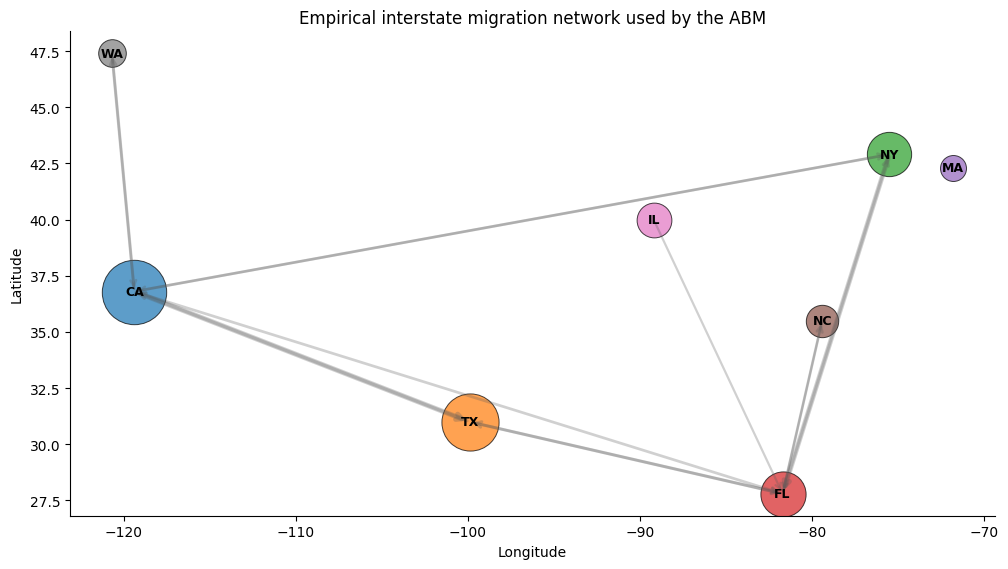

```python
# Real-world spatial presentation of the empirical migration network.
top_routes = irs_flows.nlargest(14, "returns").copy()
max_flow = top_routes["returns"].max()
pop = state_data["young_adult_population_est_18_35"]
pop_size = 350 + 1800 * (pop - pop.min()) / max(pop.max() - pop.min(), 1)

fig, ax = plt.subplots(figsize=(10.2, 5.8))
for _, row in top_routes.iterrows():
    o, d = row["origin"], row["destination"]
    y1, x1 = STATE_COORDS[o]
    y2, x2 = STATE_COORDS[d]
    lw = 0.6 + 3.0 * row["returns"] / max_flow
    ax.annotate(
        "", xy=(x2, y2), xytext=(x1, y1),
        arrowprops=dict(arrowstyle="->", lw=lw, alpha=0.28, color="0.35"),
    )

for state in STATE_CODES:
    lat, lon = STATE_COORDS[state]
    ax.scatter(lon, lat, s=pop_size[state], alpha=0.72, edgecolor="black", linewidth=0.7)
    ax.text(lon, lat, state, ha="center", va="center", fontsize=9, fontweight="bold")

ax.set_title("Empirical interstate migration network used by the ABM")
ax.set_xlabel("Longitude")
ax.set_ylabel("Latitude")
ax.spines[["top", "right"]].set_visible(False)
plt.tight_layout()
plt.show()
```

## 3. ACS PUMS empirical target and its data scope

This results build reads supplied ACS CSVs. It does not automatically download microdata or implement a STRICT_EMPIRICAL_CALIBRATION switch. The verified target comes from official 2023 ACS 1-year person ZIPs for eight current-residence states, exact ages 18–35, weighted using PWGTP.

The rebuild uses AGEP, PWGTP, MIG, MIGSP and current state in chunks. Overall move-rate and external-origin composition have distinct origin/Puerto Rico scope, documented in rebuild_scripts/acs_pums.py. Download the official state ZIPs and run that script for a fresh empirical rebuild. The current target is 3.87457656898644%. New simulation fitting and disjoint-seed validation are in calibration/results/reliable-calibration-report.html.

```python
# Load the exact empirical mobility anchor produced from the eight official 2023 ACS 1-year PUMS person files.
RESULT_CACHE = PROJECT_ROOT / "data/research"
ACS_LOCAL_PATH = RESULT_CACHE / "acs_young_adult_interstate_move_rate.csv"
ACS_BY_STATE_PATH = RESULT_CACHE / "acs_young_adult_interstate_move_rate_by_state.csv"
ACS_BY_AGE_PATH = RESULT_CACHE / "acs_young_adult_interstate_move_rate_by_age.csv"
MODEL_STATE_FIPS = {"CA":6,"TX":48,"NY":36,"FL":12,"MA":25,"NC":37,"IL":17,"WA":53}
anchor = pd.read_csv(ACS_LOCAL_PATH).iloc[0]
MOVE_RATE_TARGET = float(anchor["move_rate"])
MOVE_RATE_INFO = {"rate": MOVE_RATE_TARGET, "status": anchor["source"], "scope": anchor["scope"], "empirical": True}
print("Observed ACS 18–35 interstate move-rate target:", round(MOVE_RATE_TARGET, 5))
print("Source:", MOVE_RATE_INFO["status"])
print("Scope:", MOVE_RATE_INFO["scope"])
display(pd.DataFrame([anchor]).drop(columns=["source_files"], errors="ignore").round(5))
acs_by_state = pd.read_csv(ACS_BY_STATE_PATH)
acs_by_age = pd.read_csv(ACS_BY_AGE_PATH)
display(acs_by_state.round(5), acs_by_age.round(5))

assert json.loads((PROJECT_ROOT / "research/rebuild-report.json").read_text())["new_policy_grid_regenerated"]
```

```
Observed ACS 18–35 interstate move-rate target: 0.03875
Source: 2023 ACS 1-year PUMS person records; exact ages 18–35; PWGTP-weighted; scope=eight modeled states
Scope: eight modeled states
```

|  | year | age_min | age_max | move_rate | weighted_population | weighted_interstate_movers | unweighted_population | unweighted_interstate_movers | scope | source |
| --- | --- | --- | --- | --- | --- | --- | --- | --- | --- | --- |
| 0 | 2023 | 18 | 35 | 0.03875 | 36550523 | 1416178 | 334763 | 14273 | eight modeled states | 2023 ACS 1-year PUMS person records; exact age... |

|  | state | weighted_population | weighted_interstate_movers | unweighted_population | unweighted_interstate_movers | move_rate |
| --- | --- | --- | --- | --- | --- | --- |
| 0 | CA | 9816894 | 237097 | 92377 | 2521 | 0.02415 |
| 1 | TX | 7753949 | 279664 | 67602 | 2563 | 0.03607 |
| 2 | NY | 4744640 | 190596 | 46363 | 2117 | 0.04017 |
| 3 | FL | 4940508 | 230479 | 41385 | 2068 | 0.04665 |
| 4 | MA | 1750548 | 88648 | 17494 | 1112 | 0.05064 |
| 5 | NC | 2614025 | 158130 | 24489 | 1610 | 0.06049 |
| 6 | IL | 2976658 | 115502 | 26905 | 1122 | 0.03880 |
| 7 | WA | 1953301 | 116062 | 18148 | 1160 | 0.05942 |

|  | age | weighted_population | weighted_interstate_movers | unweighted_population | unweighted_interstate_movers | move_rate |
| --- | --- | --- | --- | --- | --- | --- |
| 0 | 18 | 1984453 | 89650 | 20949 | 1487 | 0.04518 |
| 1 | 19 | 1926402 | 99343 | 20745 | 1503 | 0.05157 |
| 2 | 20 | 1891447 | 60675 | 18593 | 813 | 0.03208 |
| 3 | 21 | 1874846 | 62336 | 17468 | 655 | 0.03325 |
| 4 | 22 | 1899336 | 88160 | 17048 | 853 | 0.04642 |
| 5 | 23 | 2008435 | 104894 | 17163 | 926 | 0.05223 |
| 6 | 24 | 1960233 | 105539 | 16842 | 887 | 0.05384 |
| 7 | 25 | 1972421 | 96942 | 17288 | 880 | 0.04915 |
| 8 | 26 | 1983682 | 89898 | 17492 | 778 | 0.04532 |
| 9 | 27 | 1983629 | 87698 | 17697 | 722 | 0.04421 |
| 10 | 28 | 2051579 | 82834 | 18212 | 719 | 0.04038 |
| 11 | 29 | 2042036 | 82769 | 18297 | 717 | 0.04053 |
| 12 | 30 | 2187257 | 70427 | 19093 | 629 | 0.03220 |
| 13 | 31 | 2111883 | 64463 | 19007 | 575 | 0.03052 |
| 14 | 32 | 2166069 | 61063 | 19639 | 574 | 0.02819 |
| 15 | 33 | 2185598 | 68198 | 19823 | 601 | 0.03120 |
| 16 | 34 | 2158685 | 53395 | 19832 | 493 | 0.02473 |
| 17 | 35 | 2162532 | 47894 | 19575 | 461 | 0.02215 |

### 3.1 External-competition scope audit (ACS PUMS)

The main ABM intentionally models eight states. To quantify the closed-system limitation rather than hide it, V7 measures what share of observed 2023 interstate in-movers to those eight states previously lived in one of the other U.S. states. This is an **empirical scope diagnostic**, not a new calibrated destination model. A full `OTHER_US` utility option would require nationwide destination-flow calibration and would change the estimand, so it is not silently inserted into the main model.

```
Weighted share of interstate in-movers originating outside the eight modeled states: 0.620
```

|  | state | external_origin_share |
| --- | --- | --- |
| 0 | CA | 0.584 |
| 4 | MA | 0.595 |
| 2 | NY | 0.600 |
| 7 | WA | 0.600 |
| 3 | FL | 0.626 |
| 1 | TX | 0.637 |
| 5 | NC | 0.644 |
| 6 | IL | 0.682 |

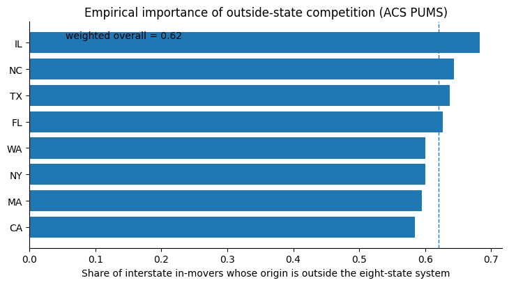

```python
external_origin_by_state = pd.read_csv(RESULT_CACHE / "pums_external_origin_competition.csv")
EXTERNAL_ORIGIN_SHARE = (
    external_origin_by_state["weighted_from_other_us"].sum()
    / external_origin_by_state["weighted_interstate_inmovers"].sum()
)
print(f"Weighted share of interstate in-movers originating outside the eight modeled states: {EXTERNAL_ORIGIN_SHARE:.3f}")
display(external_origin_by_state[["state","external_origin_share"]].sort_values("external_origin_share").round(3))

fig, ax = plt.subplots(figsize=(7.4, 4.2))
g = external_origin_by_state.sort_values("external_origin_share")
ax.barh(g["state"], g["external_origin_share"])
ax.axvline(EXTERNAL_ORIGIN_SHARE, linestyle="--", linewidth=1, label=f"weighted overall = {EXTERNAL_ORIGIN_SHARE:.2f}")
ax.set_xlabel("Share of interstate in-movers whose origin is outside the eight-state system")
ax.set_title("Empirical importance of outside-state competition (ACS PUMS)")
ax.legend(frameon=False)
ax.spines[["top","right"]].set_visible(False)
plt.tight_layout(); plt.show()
```

## 4. Policy, interaction, demography, and shock parameters

```python
# Age-specific mortality pattern for the 18–35 study population.
MORTALITY_AGE = np.arange(18, 36, dtype=float)
MORTALITY_QX = np.array([
    0.000731, 0.000837, 0.000949, 0.001065, 0.001170, 0.001259,
    0.001335, 0.001406, 0.001480, 0.001560, 0.001651, 0.001749,
    0.001849, 0.001947, 0.002040, 0.002128, 0.002216, 0.002308,
])


def mortality_probability(age):
    return np.interp(
        np.asarray(age, dtype=float),
        MORTALITY_AGE,
        MORTALITY_QX,
        left=MORTALITY_QX[0],
        right=MORTALITY_QX[-1],
    )


PARAMS = {
    # IRS-calibrated destination attractiveness
    "beta_income": float(CALIBRATED_BETA[0]),
    "beta_jobs": float(CALIBRATED_BETA[1]),
    "beta_rent": float(CALIBRATED_BETA[2]),
    "beta_distance": float(CALIBRATED_BETA[3]),
    "beta_education": float(CALIBRATED_BETA[4]),
    "beta_childcare": float(CALIBRATED_BETA[5]),

    # Stay/move and social interaction
    "beta_current_state": 3.20,
    "beta_home_state": 0.20,
    "migration_cost": 1.00,
    "temperature": 0.90,
    "beta_unemployment_push": 0.45,
    "beta_job_rejection_push": 0.75,
    "beta_peer_network": 1.00,
    "beta_coorigin": 0.60,
    "beta_social_dissatisfaction": 0.90,
    "social_satisfaction_threshold": 0.35,
    "beta_crowding": 0.00,  # optional; activated only in sensitivity analysis
    "network_k": 8,
    "annual_pair_formation_rate": 0.08,

    # Direct policy pull + capacity effects
    "beta_migration_incentive": 0.55,
    "beta_housing_signal": 0.30,
    "beta_employment_signal": 0.40,
    "housing_entry_factor": 0.80,
    "housing_policy_slots": 0.05,
    "employment_policy_slots": 0.07,
    "housing_policy_effect": 0.030,
    "employment_policy_growth": 0.020,
    # Lagged rent response to excess housing demand. 0.15 is the central value;
    # Section 13 scans 0.00/0.10/0.15/0.20 as a robustness check.
    "rent_rejection_elasticity": 0.15,
    # Smooth housing-market rationing: availability becomes probabilistic as
    # remaining capacity approaches zero, avoiding a discontinuous hard wall.
    "housing_market_softness": 0.10,
    "housing_capacity_buffer": 0.05,

    # Demography
    "international_entry_rate": 0.008,
    "birth_peak_probability": 0.065,
    "birth_age_center": 29.0,
    "birth_age_spread": 5.0,
    "max_dependent_children": 3,
}

# Shock dictionaries use model-year indices. Recovery is linear after the active period.
SHOCK_SCENARIOS = {
    "baseline": {},
    "financial_crisis": {
        "start": 5, "duration": 2, "recovery_years": 3,
        "job_slot_multiplier": 0.72,
        "wage_multiplier": 0.92,
        "mortality_multiplier": 1.0,
        "migration_cost_multiplier": 1.0,
    },
    "pandemic": {
        "start": 5, "duration": 2, "recovery_years": 2,
        "job_slot_multiplier": 0.78,
        "wage_multiplier": 0.95,
        "mortality_multiplier": 2.50,
        "migration_cost_multiplier": 1.25,
    },
    "labor_shortage": {
        "start": 5, "duration": 4, "recovery_years": 2,
        "job_slot_multiplier": 1.25,
        "wage_multiplier": 1.06,
        "mortality_multiplier": 1.0,
        "migration_cost_multiplier": 1.0,
    },
}


def policy_table(
    target_state=None,
    housing=0.0,
    employment=0.0,
    migration_incentive=0.0,
    state_incentives=None,
):
    p = pd.DataFrame(0.0, index=STATE_CODES, columns=POLICY_COLS)
    if target_state is not None:
        p.loc[target_state, "housing_policy"] = float(housing)
        p.loc[target_state, "employment_incentive"] = float(employment)
        p.loc[target_state, "migration_incentive"] = float(migration_incentive)
    if state_incentives is not None:
        for state, value in state_incentives.items():
            p.loc[state, "migration_incentive"] = float(value)
    return p


# Focal state is chosen mechanically, not because it produces a preferred result.
opportunity_index = (
    state_data["job_index"]
    + state_data["housing_capacity_index"]
    - state_data["rent_index"]
)
FOCAL_STATE = (
    (opportunity_index - opportunity_index.median())
    .abs()
    .sort_values()
    .index[0]
)
print("Focal policy state:", FOCAL_STATE, STATE_NAMES[FOCAL_STATE])
```

```
Focal policy state: NY New York
```

## 5. Agent initialization and network-structure robustness

The default initial condition remains deliberately mixed: current state and home state are sampled independently. Two distinct robustness mechanisms are now separated:

- `network_homophily_share`: share of each agent's initial contacts preferentially drawn from the same home-state group. Default `0.0` preserves the original random-network baseline; `0.5` is tested as a structured-network alternative.
- `entrant_home_local` / `entrant_network_home_bias`: replacement-entrant assumptions retained from earlier versions and tested separately.

This distinction matters because a model should not label clustering as an emergent result if it was mechanically inserted by initialization.

```python
def logistic(x):
    return 1.0 / (1.0 + np.exp(-np.clip(x, -30, 30)))



def initialise_agents(
    state_df,
    n_agents,
    seed,
    network_k=8,
    couple_share=0.35,
    network_homophily_share=0.0,
):
    rng = np.random.default_rng(seed)
    probs = state_df["young_adult_population_est_18_35"].to_numpy(dtype=float)
    probs /= probs.sum()

    states = rng.choice(STATE_CODES, size=n_agents, p=probs)
    home_states = rng.choice(STATE_CODES, size=n_agents, p=probs)
    age = rng.integers(18, 36, size=n_agents)

    college_prob = np.array([state_df.loc[s, "college_share_proxy"] for s in states])
    college_prob = np.where(age < 22, college_prob * 0.20, np.where(age < 25, college_prob * 0.60, college_prob))
    college = rng.binomial(1, np.clip(college_prob, 0.03, 0.75))
    skill = np.clip(rng.normal(1.0 + 0.18 * college, 0.15, n_agents), 0.55, 1.65)

    has_children = rng.binomial(1, logistic((age - 28) / 3.5 - 1))
    dependent_children = has_children * np.clip(rng.poisson(1.0, n_agents) + 1, 1, 3)

    income_anchor = np.array([0.65 * state_df.loc[s, "median_household_income"] for s in states])
    income = (
        income_anchor
        * (0.72 + 0.28 * skill)
        * (1.0 + 0.22 * college)
        * rng.lognormal(0.0, 0.12, n_agents)
    )

    agents = pd.DataFrame({
        "agent_id": np.arange(n_agents),
        "age": age,
        "college": college,
        "skill": skill,
        "income": income,
        "employed": np.ones(n_agents, dtype=int),
        "has_children": has_children,
        "dependent_children": dependent_children,
        "home_state": home_states,
        "state": states,
        "is_international": np.zeros(n_agents, dtype=int),
        "unemployed_years": np.zeros(n_agents, dtype=int),
        "job_rejected_last_year": np.zeros(n_agents, dtype=int),
        "last_move_year": np.full(n_agents, -99, dtype=int),
    })

    household_id = np.arange(n_agents, dtype=int)
    next_household = n_agents
    for state in STATE_CODES:
        eligible = np.where((states == state) & (age >= 22))[0]
        rng.shuffle(eligible)
        n_pairs = int((len(eligible) * couple_share) // 2)
        for a, b in eligible[: 2 * n_pairs].reshape(-1, 2):
            household_id[a] = next_household
            household_id[b] = next_household
            dep = max(int(agents.loc[a, "dependent_children"]), int(agents.loc[b, "dependent_children"]))
            if dep > 0:
                agents.loc[[a, b], "has_children"] = 1
                agents.loc[[a, b], "dependent_children"] = dep
            next_household += 1
    agents["household_id"] = household_id

    # Social-network initialization. The baseline remains random (share=0), while
    # the robustness experiment sets share=0.5 to introduce realistic co-origin
    # homophily without forcing all contacts to be co-origin.
    homophily = float(np.clip(network_homophily_share, 0.0, 1.0))
    network = np.empty((n_agents, network_k), dtype=int)
    all_idx = np.arange(n_agents)
    home_arr = agents["home_state"].to_numpy()

    for i in range(n_agents):
        pool = all_idx[all_idx != i]
        contacts = []
        k_home = int(round(network_k * homophily))
        if k_home > 0:
            same_home_pool = pool[home_arr[pool] == home_arr[i]]
            if len(same_home_pool):
                take = min(k_home, len(same_home_pool))
                contacts.extend(rng.choice(same_home_pool, size=take, replace=False).tolist())

        remaining = network_k - len(contacts)
        if remaining > 0:
            available = pool[~np.isin(pool, contacts)]
            contacts.extend(
                rng.choice(
                    available,
                    size=remaining,
                    replace=len(available) < remaining,
                ).tolist()
            )
        network[i] = contacts[:network_k]

    return agents, network
```

## 6. Interaction-driven ABM

The model combines household migration choice, social-network influence, finite housing and jobs, demographic turnover, and state-level environmental feedback. Housing is now represented as a **hybrid quantity-price constraint**: capacity can still reject excess households in the current year, but the state-specific rejection rate raises next-year rents through `rent_rejection_elasticity`. This makes excess demand partially self-correcting instead of producing only a mechanical capacity wall.

```python
class PolicySocialABM:
    """Agent-based model of 18-35 interstate migration across the eight modeled states.

    Each simulated year, agents choose a destination from state utilities (income,
    housing cost, jobs, amenities, policy incentives, distance decay) plus the
    influence of their social-network contacts. Housing and job capacity limit
    in-migration, and rejected movers feed back into next-year rents.

    Key arguments:
        interaction_strength: scales the social-influence term (1.0 = baseline).
        shocks: optional table of year-specific shocks to state attributes.
        network_homophily_share: share of contacts drawn from the agent's home state.
        record_events: keep a per-move event log (disable to save memory).
    """
    def __init__(
        self,
        state_df,
        policies,
        n_agents=EXPERIMENT_AGENTS,
        years=EXPERIMENT_YEARS,
        seed=RANDOM_SEED,
        params=None,
        interaction_strength=1.0,
        shocks=None,
        entrant_home_local=False,
        entrant_network_home_bias=False,
        network_homophily_share=0.0,
        record_events=True,
    ):
        self.base_state = state_df.copy()
        self.state = state_df.copy()
        self.policies = policies.copy()
        self.n_agents = int(n_agents)
        self.years = int(years)
        self.seed = int(seed)
        self.params = PARAMS.copy() if params is None else params.copy()
        self.interaction_strength = float(interaction_strength)
        self.shocks = {} if shocks is None else dict(shocks)
        self.entrant_home_local = bool(entrant_home_local)
        self.entrant_network_home_bias = bool(entrant_network_home_bias)
        self.network_homophily_share = float(np.clip(network_homophily_share, 0.0, 1.0))
        self.record_events = bool(record_events)

        self.params["beta_peer_network"] = PARAMS["beta_peer_network"] * self.interaction_strength
        self.params["beta_coorigin"] = PARAMS["beta_coorigin"] * self.interaction_strength
        self.params["beta_social_dissatisfaction"] = PARAMS["beta_social_dissatisfaction"] * self.interaction_strength

        self.agents, self.network = initialise_agents(
            state_df,
            n_agents=self.n_agents,
            seed=self.seed + 1000,
            network_k=self.params["network_k"],
            network_homophily_share=self.network_homophily_share,
        )
        self.network_k = self.params["network_k"]
        self.next_household_id = int(self.agents["household_id"].max() + 1)

        self.history = []
        self.move_history = []
        self.decision_rows = []
        self.mechanism_rows = []
        self.demography_rows = []
        self.snapshots = {}
        self.job_rejection_by_state = {}
        self.unfilled_jobs_by_state = {}
        self.housing_rejection_by_state = {}
        self.previous_counts = self._counts()
        self.initial_counts = self.previous_counts.copy()

        self._employment_step(-1)
        self._snapshot(BASE_YEAR)

    def _rng(self, code, t):
        return np.random.default_rng(np.random.SeedSequence([self.seed, int(code), int(t) + 100]))

    def _counts(self):
        return self.agents["state"].value_counts().reindex(STATE_CODES, fill_value=0).astype(float)

    def _state_indices(self):
        return pd.Categorical(self.agents["state"], categories=STATE_CODES).codes

    def _home_indices(self):
        return pd.Categorical(self.agents["home_state"], categories=STATE_CODES).codes

    def _shock_factors(self, t):
        if not self.shocks:
            return {
                "job_slot_multiplier": 1.0,
                "wage_multiplier": 1.0,
                "mortality_multiplier": 1.0,
                "migration_cost_multiplier": 1.0,
            }

        start = int(self.shocks.get("start", 0))
        duration = int(self.shocks.get("duration", 0))
        recovery = int(self.shocks.get("recovery_years", 0))

        if t < start:
            intensity = 0.0
        elif t < start + duration:
            intensity = 1.0
        elif recovery > 0 and t < start + duration + recovery:
            elapsed = t - (start + duration) + 1
            intensity = max(0.0, 1.0 - elapsed / (recovery + 1))
        else:
            intensity = 0.0

        def blend(key):
            target = float(self.shocks.get(key, 1.0))
            return 1.0 + intensity * (target - 1.0)

        return {
            "job_slot_multiplier": blend("job_slot_multiplier"),
            "wage_multiplier": blend("wage_multiplier"),
            "mortality_multiplier": blend("mortality_multiplier"),
            "migration_cost_multiplier": blend("migration_cost_multiplier"),
        }

    def _household_formation_step(self, t):
        a = self.agents
        rng = self._rng(15, t)
        hh = a["household_id"].to_numpy()
        sizes = a["household_id"].map(a["household_id"].value_counts()).to_numpy()
        eligible = (a["age"].to_numpy() >= 22) & (sizes == 1)
        states = a["state"].to_numpy()
        for state in STATE_CODES:
            candidates = np.where(eligible & (states == state))[0]
            if len(candidates) < 2:
                continue
            rng.shuffle(candidates)
            n_adults = int(len(candidates) * self.params["annual_pair_formation_rate"])
            n_adults -= n_adults % 2
            for i, j in candidates[:n_adults].reshape(-1, 2):
                hid = self.next_household_id
                self.next_household_id += 1
                a.loc[[i, j], "household_id"] = hid
                dep = max(int(a.loc[i, "dependent_children"]), int(a.loc[j, "dependent_children"]))
                if dep > 0:
                    a.loc[[i, j], "has_children"] = 1
                    a.loc[[i, j], "dependent_children"] = dep

    def _family_step(self, t):
        a = self.agents
        rng = self._rng(17, t)
        grouped = a.groupby("household_id", sort=False)
        hh_age = grouped["age"].mean()
        hh_children = grouped["dependent_children"].max()
        eligible = hh_age.index[
            (hh_age.to_numpy() >= 20)
            & (hh_age.to_numpy() <= 35)
            & (hh_children.to_numpy() < self.params["max_dependent_children"])
        ]
        if len(eligible) == 0:
            return 0
        ages = hh_age.loc[eligible].to_numpy()
        existing = hh_children.loc[eligible].to_numpy()
        age_profile = np.exp(-0.5 * ((ages - self.params["birth_age_center"]) / self.params["birth_age_spread"]) ** 2)
        p = np.clip(self.params["birth_peak_probability"] * age_profile * (1.0 - 0.18 * existing), 0, 0.09)
        selected = eligible[rng.random(len(eligible)) < p]
        for hid in selected:
            mask = a["household_id"] == hid
            current = int(a.loc[mask, "dependent_children"].max())
            a.loc[mask, "has_children"] = 1
            a.loc[mask, "dependent_children"] = min(current + 1, self.params["max_dependent_children"])
        return int(len(selected))
```

```python
    def _rewire_agent(self, i, t):
        rng = self._rng(71 + i % 11, t + i)
        n = len(self.agents)
        all_idx = np.arange(n)
        pool = all_idx[all_idx != i]
        home = self.agents["home_state"].to_numpy()

        # Preserve the model-level homophily treatment for replacement entrants.
        # The legacy entrant_network_home_bias switch implies at least 50% same-home
        # contacts but does not overwrite a stronger explicit homophily setting.
        target_homophily = self.network_homophily_share
        if self.entrant_network_home_bias:
            target_homophily = max(target_homophily, 0.50)

        contacts = []
        k_home = int(round(self.network_k * target_homophily))
        if k_home > 0:
            same_home = pool[home[pool] == home[i]]
            if len(same_home):
                take = min(k_home, len(same_home))
                contacts.extend(rng.choice(same_home, size=take, replace=False).tolist())

        remaining = self.network_k - len(contacts)
        if remaining > 0:
            available = pool[~np.isin(pool, contacts)]
            contacts.extend(
                rng.choice(
                    available,
                    size=remaining,
                    replace=len(available) < remaining,
                ).tolist()
            )
        self.network[i] = contacts[:self.network_k]

        # Replace inbound links while approximately preserving the sender's
        # homophily treatment rather than rewiring those links completely at random.
        rows, cols = np.where(self.network == i)
        for r, c in zip(rows, cols):
            candidates = all_idx[(all_idx != r) & (all_idx != i)]
            choose_pool = candidates
            if target_homophily > 0 and rng.random() < target_homophily:
                same_home_r = candidates[home[candidates] == home[r]]
                if len(same_home_r):
                    choose_pool = same_home_r
            self.network[r, c] = int(rng.choice(choose_pool))

    def _demography_step(self, t):
        """Age agents one year; replace deaths and agents aged out of 18-35 with new entrants.

        Mortality is shock-scaled. Entrants are domestic (age 18) or international
        (Poisson-drawn count, ages around 27, placed by job/rent attractiveness).
        """
        a = self.agents
        rng = self._rng(61, t)
        factors = self._shock_factors(t)
        age = a["age"].to_numpy(dtype=int)
        mortality = np.clip(mortality_probability(age) * factors["mortality_multiplier"], 0, 0.20)
        deaths = rng.random(len(a)) < mortality
        next_age = age + 1
        age_out = (next_age > 35) & (~deaths)
        outgoing = np.where(deaths | age_out)[0]
        survivor = ~(deaths | age_out)
        a.loc[survivor, "age"] = next_age[survivor]

        intl_entries = 0
        domestic_entries = 0
        if len(outgoing):
            probs = self.base_state["young_adult_population_est_18_35"].to_numpy(dtype=float)
            probs /= probs.sum()
            shuffled = rng.permutation(outgoing)
            expected_intl = self.params["international_entry_rate"] * self.n_agents
            n_intl = min(len(outgoing), int(rng.poisson(expected_intl)))
            intl_idx = shuffled[:n_intl]
            dom_idx = shuffled[n_intl:]
            intl_entries = len(intl_idx)
            domestic_entries = len(dom_idx)

            if len(dom_idx):
                states = rng.choice(STATE_CODES, size=len(dom_idx), p=probs)
                homes = states.copy() if self.entrant_home_local else rng.choice(STATE_CODES, size=len(dom_idx), p=probs)
                a.loc[dom_idx, "age"] = 18
                a.loc[dom_idx, "state"] = states
                a.loc[dom_idx, "home_state"] = homes
                a.loc[dom_idx, "is_international"] = 0

            if len(intl_idx):
                attract = probs * self.state["job_index"].to_numpy() / np.maximum(self.state["rent_index"].to_numpy(), 0.5)
                attract /= attract.sum()
                states = rng.choice(STATE_CODES, size=len(intl_idx), p=attract)
                homes = states.copy() if self.entrant_home_local else rng.choice(STATE_CODES, size=len(intl_idx), p=probs)
                a.loc[intl_idx, "age"] = np.clip(np.rint(rng.normal(27, 4.5, len(intl_idx))), 18, 35).astype(int)
                a.loc[intl_idx, "state"] = states
                a.loc[intl_idx, "home_state"] = homes
                a.loc[intl_idx, "is_international"] = 1

            entrant_states = a.loc[outgoing, "state"].to_numpy()
            entrant_ages = a.loc[outgoing, "age"].to_numpy(dtype=int)
            college_prob = np.array([self.base_state.loc[s, "college_share_proxy"] for s in entrant_states])
            college_prob = np.where(entrant_ages < 22, college_prob * 0.20, np.where(entrant_ages < 25, college_prob * 0.60, college_prob))
            college = rng.binomial(1, np.clip(college_prob, 0.03, 0.75))
            skill = np.clip(rng.normal(1.0 + 0.18 * college, 0.15, len(outgoing)), 0.55, 1.65)
            anchor = np.array([0.65 * self.base_state.loc[s, "median_household_income"] for s in entrant_states])

            a.loc[outgoing, "college"] = college
            a.loc[outgoing, "skill"] = skill
            a.loc[outgoing, "income"] = anchor * (0.72 + 0.28 * skill) * (1 + 0.22 * college) * rng.lognormal(0, 0.12, len(outgoing))
            a.loc[outgoing, "employed"] = 0
            a.loc[outgoing, "has_children"] = 0
            a.loc[outgoing, "dependent_children"] = 0
            a.loc[outgoing, "unemployed_years"] = 0
            a.loc[outgoing, "job_rejected_last_year"] = 0
            a.loc[outgoing, "last_move_year"] = -99

            for i in outgoing:
                a.loc[i, "household_id"] = self.next_household_id
                self.next_household_id += 1
                self._rewire_agent(int(i), t)

        self.demography_rows.append({
            "year": BASE_YEAR + t + 1,
            "deaths": int(deaths.sum()),
            "age_outs": int(age_out.sum()),
            "domestic_entries": int(domestic_entries),
            "international_entries": int(intl_entries),
        })
```

```python
    def _social_components(self, members, destination, state_idx, home_idx, group_counts, group_totals):
        peer = np.mean([
            np.mean(state_idx[self.network[i]] == destination)
            for i in members
        ])
        coorigin = np.mean([
            group_counts[home_idx[i], destination] / max(group_totals[home_idx[i]], 1)
            for i in members
        ])
        home = np.mean([home_idx[i] == destination for i in members])
        attachment = (
            SOCIAL_UTILITY_WEIGHTS["peer"] * peer
            + SOCIAL_UTILITY_WEIGHTS["coorigin"] * coorigin
            + SOCIAL_UTILITY_WEIGHTS["home"] * home
        ) / (
            SOCIAL_UTILITY_WEIGHTS["peer"]
            + SOCIAL_UTILITY_WEIGHTS["coorigin"]
            + SOCIAL_UTILITY_WEIGHTS["home"]
        )
        return float(peer), float(coorigin), float(home), float(attachment)

    def _base_utility_matrix(self, t):
        a = self.agents
        n = len(a)
        S = len(STATE_CODES)
        current = self._state_indices()
        home = self._home_indices()
        factors = self._shock_factors(t)

        wage = self.state["wage_index"].to_numpy() * factors["wage_multiplier"]
        jobs = self.state["job_index"].to_numpy()
        rent = self.state["rent_index"].to_numpy()
        income_anchor = 0.65 * self.base_state["median_household_income"].to_numpy() * (wage / self.base_state["wage_index"].to_numpy())
        expected_income = (
            income_anchor[None, :]
            * (0.72 + 0.28 * a["skill"].to_numpy()[:, None])
            * (1.0 + 0.22 * a["college"].to_numpy()[:, None])
        )

        U = (
            self.params["beta_income"] * np.log(np.maximum(expected_income, 1000) / np.median(income_anchor))
            + self.params["beta_jobs"] * jobs[None, :]
            - self.params["beta_rent"] * rent[None, :]
            + DESTINATION_EFFECTS.to_numpy()[None, :]
            + self.params["beta_housing_signal"] * self.policies["housing_policy"].to_numpy()[None, :]
            + self.params["beta_employment_signal"] * self.policies["employment_incentive"].to_numpy()[None, :]
            + self.params["beta_migration_incentive"] * self.policies["migration_incentive"].to_numpy()[None, :]
        )
        U -= self.params["beta_distance"] * distance_index.to_numpy()[current, :]
        U -= (
            self.params["migration_cost"]
            * factors["migration_cost_multiplier"]
            * (np.arange(S)[None, :] != current[:, None])
        )

        # Optional crowding cost relative to each state's initial representative population.
        if self.params.get("beta_crowding", 0.0) > 0:
            crowding = np.maximum(self._counts().to_numpy() / np.maximum(self.initial_counts.to_numpy(), 1) - 1.0, 0.0)
            U -= self.params["beta_crowding"] * crowding[None, :]

        U[np.arange(n), current] += (
            self.params["beta_current_state"]
            - self.params["beta_unemployment_push"] * np.minimum(a["unemployed_years"].to_numpy(), 3)
            - self.params["beta_job_rejection_push"] * a["job_rejected_last_year"].to_numpy()
        )
        U[np.arange(n), home] += self.params["beta_home_state"]
        return U, current, home

    def _migration_step(self, t):
        a = self.agents
        S = len(STATE_CODES)
        base_U, state_idx, home_idx = self._base_utility_matrix(t)
        old_states = a["state"].to_numpy().copy()
        state_idx = state_idx.copy()

        group_counts = np.zeros((S, S), dtype=int)
        np.add.at(group_counts, (home_idx, state_idx), 1)
        group_totals = group_counts.sum(axis=1)

        household_counts = a.groupby("state")["household_id"].nunique().reindex(STATE_CODES, fill_value=0).to_numpy()
        housing_slots = np.maximum(
            1,
            np.round(
                household_counts * self.base_state["vacancy_rate"].to_numpy() * self.params["housing_entry_factor"]
                + household_counts * self.policies["housing_policy"].to_numpy() * self.params["housing_policy_slots"]
            ),
        ).astype(int)
        housing_capacity = housing_slots.copy()

        households = list(a.groupby("household_id", sort=False).indices.items())
        rng = self._rng(11, t)
        order = rng.permutation(len(households))

        proposed = rejected = 0
        proposed_by_state = np.zeros(S, dtype=int)
        rejected_by_state = np.zeros(S, dtype=int)
        move_rows = []
        # Target proposal/rejection counts are household-level because housing
        # capacity is allocated to households. Accepted inflow, chain counts,
        # and mover social outcomes are person-level to match agent-year rates.
        target_proposed = target_rejected = 0
        target_accepted_agents = 0
        chain_count_agents = 0
        social_cost_sum = social_cost_n = 0
        origin_attachment_sum = 0.0

        for position in order:
            household_id, members = households[position]
            members = np.asarray(members, dtype=int)
            origin = int(state_idx[members[0]])
            hu = base_U[members].mean(axis=0)

            peer_pull = np.zeros(S)
            co_pull = np.zeros(S)
            for i in members:
                contacts = state_idx[self.network[i]]
                peer_pull += np.bincount(contacts, minlength=S) / self.network_k
                co_pull += group_counts[home_idx[i]] / max(group_totals[home_idx[i]], 1)
            hu += self.params["beta_peer_network"] * peer_pull / len(members)
            hu += self.params["beta_coorigin"] * co_pull / len(members)

            origin_peer, origin_co, origin_home, origin_attach = self._social_components(
                members, origin, state_idx, home_idx, group_counts, group_totals
            )
            dissatisfaction = max(0.0, self.params["social_satisfaction_threshold"] - origin_peer)
            hu[origin] -= self.params["beta_social_dissatisfaction"] * dissatisfaction

            z = hu / self.params["temperature"]
            z -= z.max()
            prob = np.exp(z)
            prob /= prob.sum()
            dest = int(rng.choice(S, p=prob))
```

```python
            dest_peer, dest_co, dest_home, dest_attach = self._social_components(
                members, dest, state_idx, home_idx, group_counts, group_totals
            )
            social_cost = origin_attach - dest_attach
            recent_contact = False
            contact_ids = np.unique(np.concatenate([self.network[i] for i in members]))
            if len(contact_ids):
                recent_contact = bool(np.any(
                    (state_idx[contact_ids] == dest)
                    & (a.loc[contact_ids, "last_move_year"].to_numpy() >= max(0, t - 2))
                    & (a.loc[contact_ids, "last_move_year"].to_numpy() >= 0)
                ))

            is_move = dest != origin
            accepted = False
            housing_rejected = False

            if is_move:
                proposed += 1
                proposed_by_state[dest] += 1
                if STATE_CODES[dest] == FOCAL_STATE:
                    target_proposed += 1

                # Smooth housing feasibility rather than a deterministic hard wall.
                # When capacity is plentiful, acceptance is almost certain; near or
                # beyond nominal capacity, probability falls smoothly. Rejections then
                # raise next-year rent through _environment_step.
                nominal_capacity = max(float(housing_capacity[dest]), 1.0)
                remaining_ratio = float(housing_slots[dest]) / nominal_capacity
                softness = max(float(self.params.get("housing_market_softness", 0.10)), 1e-4)
                buffer = float(self.params.get("housing_capacity_buffer", 0.05))
                housing_accept_prob = float(logistic((remaining_ratio - buffer) / softness))

                if rng.random() > housing_accept_prob:
                    rejected += 1
                    rejected_by_state[dest] += 1
                    housing_rejected = True
                    if STATE_CODES[dest] == FOCAL_STATE:
                        target_rejected += 1
                else:
                    accepted = True
                    housing_slots[dest] -= 1
                    housing_slots[origin] += 1
                    if STATE_CODES[dest] == FOCAL_STATE:
                        n_people = len(members)
                        target_accepted_agents += n_people
                        chain_count_agents += int(recent_contact) * n_people
                        social_cost_sum += social_cost * n_people
                        origin_attachment_sum += origin_attach * n_people
                        social_cost_n += n_people

                    for i in members:
                        group_counts[home_idx[i], state_idx[i]] -= 1
                        group_counts[home_idx[i], dest] += 1
                        state_idx[i] = dest
                        a.loc[i, "last_move_year"] = t
                        if self.record_events:
                            move_rows.append({
                                "year": BASE_YEAR + t + 1,
                                "agent_id": int(a.loc[i, "agent_id"]),
                                "household_id": int(a.loc[i, "household_id"]),
                                "origin": STATE_CODES[origin],
                                "destination": STATE_CODES[dest],
                                "home_state": a.loc[i, "home_state"],
                                "origin_peer_share": origin_peer,
                                "origin_coorigin_share": origin_co,
                                "destination_peer_share": dest_peer,
                                "destination_coorigin_share": dest_co,
                                "origin_social_attachment": origin_attach,
                                "destination_social_attachment": dest_attach,
                                "social_cost": social_cost,
                                "chain_move": int(recent_contact),
                            })

            if self.record_events:
                self.decision_rows.append({
                    "year": BASE_YEAR + t + 1,
                    "household_id": int(household_id),
                    "origin": STATE_CODES[origin],
                    "chosen_destination": STATE_CODES[dest],
                    "proposed_move": int(is_move),
                    "accepted_move": int(is_move and accepted),
                    "housing_rejected": int(housing_rejected),
                    "origin_peer_share": origin_peer,
                    "origin_coorigin_share": origin_co,
                    "origin_social_attachment": origin_attach,
                    "destination_social_attachment": dest_attach,
                    "social_cost": social_cost,
                    "chain_move": int(recent_contact and is_move and accepted),
                })

        new_states = np.array(STATE_CODES, dtype=object)[state_idx]
        a["state"] = new_states
        if self.record_events and move_rows:
            self.move_history.append(pd.DataFrame(move_rows))

        self.housing_rejection_by_state[t] = {
            state: (rejected_by_state[j] / max(proposed_by_state[j], 1))
            for j, state in enumerate(STATE_CODES)
        }

        self.mechanism_rows.append({
            "year": BASE_YEAR + t + 1,
            "target_proposed": target_proposed,
            "target_accepted": target_accepted_agents,
            "target_housing_rejected": target_rejected,
            "target_chain_moves": chain_count_agents,
            "target_social_cost_sum": social_cost_sum,
            "target_origin_attachment_sum": origin_attachment_sum,
            "target_social_cost_n": social_cost_n,
        })

        return old_states, new_states, proposed, rejected

    def _employment_step(self, t):
        a = self.agents
        n = len(a)
        rng = self._rng(37, t)
        factors = self._shock_factors(t)
        employed = np.zeros(n, dtype=int)
        rejected_flag = np.zeros(n, dtype=int)
        states = a["state"].to_numpy()
        state_rejection = {}
        state_unfilled = {}
```

```python
        for state in STATE_CODES:
            mask = states == state
            applicants = np.where(mask)[0]
            if len(applicants) == 0:
                state_rejection[state] = np.nan
                state_unfilled[state] = 0
                continue

            slot_rate = np.clip(
                0.80
                + 0.16 * (self.state.loc[state, "job_index"] - 1.0)
                + self.params["employment_policy_slots"] * self.policies.loc[state, "employment_incentive"],
                0.60,
                1.20,
            )
            slots = int(round(slot_rate * mask.sum() * factors["job_slot_multiplier"]))
            order = rng.permutation(applicants)
            remaining = slots
            for i in order:
                if remaining <= 0:
                    break
                p_match = logistic(
                    2.0
                    + 0.8 * (a.loc[i, "skill"] - 1.0)
                    + 0.30 * a.loc[i, "college"]
                    - 0.10 * min(a.loc[i, "unemployed_years"], 3)
                )
                if rng.random() < p_match:
                    employed[i] = 1
                    remaining -= 1

            rejected_here = applicants[employed[applicants] == 0]
            rejected_flag[rejected_here] = 1
            state_rejection[state] = len(rejected_here) / max(len(applicants), 1)
            state_unfilled[state] = max(remaining, 0)

        self.job_rejection_by_state[t] = state_rejection
        self.unfilled_jobs_by_state[t] = state_unfilled
        a["employed"] = employed
        a["job_rejected_last_year"] = rejected_flag
        a["unemployed_years"] = np.where(employed == 1, 0, a["unemployed_years"].to_numpy() + 1)

        wage = a["state"].map(self.state["wage_index"]).to_numpy() * factors["wage_multiplier"]
        base_wage = a["state"].map(self.base_state["wage_index"]).to_numpy()
        anchor = 0.65 * a["state"].map(self.base_state["median_household_income"]).to_numpy()
        income = (
            anchor * (wage / base_wage)
            * (0.72 + 0.28 * a["skill"].to_numpy())
            * (1.0 + 0.22 * a["college"].to_numpy())
            * np.where(employed == 1, 1.0, 0.34)
        )
        a["income"] = income * self._rng(41, t).lognormal(0, 0.04, n)

    def _environment_step(self):
        current = self._counts()
        growth = (current - self.previous_counts) / np.maximum(self.previous_counts, 1.0)

        # State-specific excess housing demand is translated into next-year rent
        # pressure. Current-year feasibility is soft/probabilistic near capacity,
        # while this lagged price channel dampens subsequent demand.
        if self.housing_rejection_by_state:
            latest_t = max(self.housing_rejection_by_state)
            rejection_rate = pd.Series(
                self.housing_rejection_by_state[latest_t],
                index=STATE_CODES,
                dtype=float,
            ).fillna(0.0)
        else:
            rejection_rate = pd.Series(0.0, index=STATE_CODES)
        rent_pressure = self.params.get("rent_rejection_elasticity", 0.0) * rejection_rate

        rent_growth = (
            0.10 * growth
            - self.params["housing_policy_effect"] * self.policies["housing_policy"]
            + 0.005 * (1.0 / self.state["housing_capacity_index"] - 1.0)
            + rent_pressure
        ).clip(-0.04, 0.12)
        self.state["rent_index"] = (self.state["rent_index"] * (1 + rent_growth)).clip(0.70, 1.80)

        skill = self.agents.groupby("state")["skill"].mean().reindex(STATE_CODES).fillna(1.0)
        job_growth = (
            0.008 * (skill - 1.0)
            + 0.008 * growth.clip(-0.15, 0.15)
            + self.params["employment_policy_growth"] * self.policies["employment_incentive"]
        ).clip(-0.04, 0.06)
        self.state["job_index"] = (self.state["job_index"] * (1 + job_growth)).clip(0.75, 1.40)
        self.previous_counts = current

    def _agent_social_utility_components(self):
        a = self.agents
        state_idx = self._state_indices()
        home_idx = self._home_indices()
        contact_state = state_idx[self.network]
        peer = (contact_state == state_idx[:, None]).mean(axis=1)

        S = len(STATE_CODES)
        counts = np.zeros((S, S), dtype=int)
        np.add.at(counts, (home_idx, state_idx), 1)
        totals = counts.sum(axis=1)
        co = np.zeros(len(a), dtype=float)
        valid = totals[home_idx] > 1
        co[valid] = (counts[home_idx[valid], state_idx[valid]] - 1) / (totals[home_idx[valid]] - 1)
        home = (state_idx == home_idx).astype(float)

        monthly = self.base_state["median_gross_rent_monthly"] * (self.state["rent_index"] / self.base_state["rent_index"])
        rent_burden = a["state"].map(monthly).to_numpy() * 12 / np.maximum(a["income"].to_numpy(), 12000)
        affordability = 1 - np.clip(rent_burden / 0.60, 0, 1)
        income_rel = a["income"].to_numpy() / max(a["income"].median(), 1)
        income_score = logistic(np.log(np.maximum(income_rel, 0.05)))

        total = (
            SOCIAL_UTILITY_WEIGHTS["peer"] * peer
            + SOCIAL_UTILITY_WEIGHTS["coorigin"] * co
            + SOCIAL_UTILITY_WEIGHTS["home"] * home
            + SOCIAL_UTILITY_WEIGHTS["employment"] * a["employed"].to_numpy()
            + SOCIAL_UTILITY_WEIGHTS["income"] * income_score
            + SOCIAL_UTILITY_WEIGHTS["affordability"] * affordability
        )
        return peer, co, home, rent_burden, total

    def _record_metrics(self, t, old_states, new_states, proposed, rejected, births):
        peer, co, home, rent_burden, social_utility = self._agent_social_utility_components()
        current_states = self.agents["state"].to_numpy()
        pop_share = self._counts() / len(self.agents)
        system = {
            "peer_colocation": float(np.mean(peer)),
            "coorigin_clustering": float(np.mean(co)),
            "population_hhi": float((pop_share ** 2).sum()),
            "move_rate": float(np.mean(old_states != new_states)),
            "housing_rejection_rate": rejected / max(proposed, 1),
            "mean_social_utility_index": float(np.mean(social_utility)),
            "mean_rent_burden_system": float(np.mean(rent_burden)),
            "births": int(births),
            "unfilled_jobs": int(sum(self.unfilled_jobs_by_state.get(t, {}).values())),
        }
        for state in STATE_CODES:
            mask = current_states == state
            g = self.agents.loc[mask]
            inflow = int(((old_states != state) & (new_states == state)).sum())
            outflow = int(((old_states == state) & (new_states != state)).sum())
            self.history.append({
                "year": BASE_YEAR + t + 1,
                "state": state,
                "population": len(g),
                "inflow": inflow,
                "outflow": outflow,
                "net_migration": inflow - outflow,
                "employment_rate": g["employed"].mean() if len(g) else np.nan,
                "mean_income": g["income"].mean() if len(g) else np.nan,
                "rent_index": self.state.loc[state, "rent_index"],
                "job_rejection_rate_state": self.job_rejection_by_state.get(t, {}).get(state, np.nan),
                "unfilled_jobs_state": self.unfilled_jobs_by_state.get(t, {}).get(state, 0),
                **system,
            })
```

```python
    def _snapshot(self, year):
        self.snapshots[year] = self.agents[[
            "agent_id", "state", "home_state", "age", "employed",
            "household_id", "has_children", "is_international"
        ]].copy()

    def step(self, t):
        """Run one simulated year: demography, households, family, migration, jobs, environment, metrics."""
        self._demography_step(t)
        self._household_formation_step(t)
        births = self._family_step(t)
        old_states, new_states, proposed, rejected = self._migration_step(t)
        self._employment_step(t)
        self._environment_step()
        self._record_metrics(t, old_states, new_states, proposed, rejected, births)
        if t + 1 in {5, 10, 15, 20}:
            self._snapshot(BASE_YEAR + t + 1)

    def run(self):
        """Simulate all years; return (yearly history, move log, snapshots at years 5/10/15/20)."""
        for t in range(self.years):
            self.step(t)
        history = pd.DataFrame(self.history)
        moves = (
            pd.concat(self.move_history, ignore_index=True)
            if self.move_history
            else pd.DataFrame(columns=["year", "agent_id", "origin", "destination"])
        )
        return history, moves, self.snapshots

    def mechanism_history(self):
        return pd.DataFrame(self.mechanism_rows)

    def decision_history(self):
        return pd.DataFrame(self.decision_rows)
```

## 7. Independently validated, design-specific stay calibration

The target is the independently reconstructed ACS 18–35 interstate move rate (0.0387457656898644). The 1000-agent, 20-year design uses beta 3.8250; the 600-agent, 12-year and 15-year designs use beta 3.8200, with separate training and independent validation seeds. See `calibration/reliable-calibration` and `research/calibration-600x15` for grids, seed results, intervals and protocols. Final scalar parameters use four decimal places; fitting calculations keep full precision.

```python
PARAM_DECIMALS = 4
move_rate_calibration = pd.read_csv(RESULT_CACHE / "move_rate_calibration.csv")
PARAMS["beta_current_state"] = round(FITTED_CONFIG["beta_by_design"]["600x12"], PARAM_DECIMALS)
display(move_rate_calibration.round(6))
print("Design-specific beta: baseline 1000x20", FITTED_CONFIG["beta_by_design"]["1000x20"],
      "; policy 600x12", PARAMS["beta_current_state"], "; shock/entrant 600x15", FITTED_CONFIG["beta_by_design"]["600x15"])
```

|  | design | beta_current_state | simulated_move_rate | target_move_rate | absolute_error | validation_passed |
| --- | --- | --- | --- | --- | --- | --- |
| 0 | 1000x20 | 3.825 | 0.038747 | 0.038746 | 0.000001 | True |
| 1 | 600x12 | 3.820 | 0.038819 | 0.038746 | 0.000074 | True |
| 2 | 600x15 | 3.820 | 0.038795 | 0.038746 | 0.000049 | True |

```
Design-specific beta: baseline 1000x20 3.825 ; policy 600x12 3.82 ; shock/entrant 600x15 3.82
```

## 8. Step 1 - no-policy reality baseline

The baseline uses 20 annual rounds and eight seeds. It reports mobility, clustering, housing pressure, unfilled jobs, and the **model social utility index**. The index is a model diagnostic assembled from peer co-location, co-origin concentration, home-state attachment, employment, relative income, and affordability; it should not be interpreted as a validated subjective-well-being survey score.

```python
baseline_runs = pd.read_csv(RESULT_CACHE / "baseline_runs.csv")
baseline_summary = baseline_runs.select_dtypes(include="number").agg(["mean", "std"]).T
display(baseline_summary.loc[[
    "move_rate", "coorigin_clustering", "peer_colocation",
    "housing_rejection", "mean_social_utility_index", "unfilled_jobs"
]].round(3))
print(f"Baseline mean move rate = {baseline_runs['move_rate'].mean():.4f}; ACS calibration target = {MOVE_RATE_TARGET:.4f}.")
```

|  | mean | std |
| --- | --- | --- |
| move_rate | 0.038 | 0.001 |
| coorigin_clustering | 0.183 | 0.008 |
| peer_colocation | 0.191 | 0.011 |
| housing_rejection | 0.011 | 0.008 |
| mean_social_utility_index | 0.352 | 0.005 |
| unfilled_jobs | 0.144 | 0.115 |

```
Baseline mean move rate = 0.0384; ACS calibration target = 0.0387.
```

## 9. Step 2 — targeted policy × social-tie strength

A single focal state receives the intervention. The cross experiment separates housing policy, employment policy, and a combined package. Every active policy also contains a direct migration incentive term so the model can test how much explicit pull is needed to overcome local social attachment.

```python
INTERACTION_LEVELS = {"weak": 0.60, "medium": 1.00, "strong": 1.40}
POLICY_TYPES = ["baseline", "housing", "employment", "combined"]
STANDARD_INTENSITY = 1.0
cross_runs = pd.read_csv(RESULT_CACHE / "cross_experiment_runs.csv")
cross_summary = pd.read_csv(RESULT_CACHE / "cross_experiment_summary.csv")
display(cross_summary.round(3))
```

|  | interaction | policy | target_inflow_rate | mover_origin_attachment | social_cost | chain_share | housing_rejection | job_rejection | clustering | peer_colocation | social_utility_index |
| --- | --- | --- | --- | --- | --- | --- | --- | --- | --- | --- | --- |
| 0 | medium | baseline | 0.005 | 0.119 | -0.019 | 0.057 | 0.003 | 0.200 | 0.177 | 0.187 | 0.348 |
| 1 | medium | combined | 0.022 | 0.115 | -0.122 | 0.398 | 0.093 | 0.123 | 0.199 | 0.215 | 0.370 |
| 2 | medium | employment | 0.010 | 0.118 | -0.055 | 0.188 | 0.089 | 0.124 | 0.180 | 0.187 | 0.352 |
| 3 | medium | housing | 0.010 | 0.112 | -0.057 | 0.200 | 0.017 | 0.200 | 0.177 | 0.183 | 0.350 |
| 4 | strong | baseline | 0.005 | 0.126 | -0.015 | 0.096 | 0.006 | 0.201 | 0.185 | 0.199 | 0.354 |
| 5 | strong | combined | 0.025 | 0.115 | -0.131 | 0.462 | 0.132 | 0.121 | 0.219 | 0.240 | 0.382 |
| 6 | strong | employment | 0.012 | 0.118 | -0.066 | 0.262 | 0.137 | 0.122 | 0.185 | 0.201 | 0.356 |
| 7 | strong | housing | 0.011 | 0.108 | -0.076 | 0.260 | 0.012 | 0.200 | 0.180 | 0.196 | 0.355 |
| 8 | weak | baseline | 0.005 | 0.146 | 0.017 | 0.083 | 0.005 | 0.200 | 0.168 | 0.171 | 0.341 |
| 9 | weak | combined | 0.020 | 0.123 | -0.094 | 0.368 | 0.077 | 0.123 | 0.190 | 0.202 | 0.364 |
| 10 | weak | employment | 0.010 | 0.124 | -0.045 | 0.205 | 0.104 | 0.124 | 0.171 | 0.177 | 0.347 |
| 11 | weak | housing | 0.008 | 0.129 | -0.026 | 0.175 | 0.000 | 0.200 | 0.168 | 0.171 | 0.345 |

### Paired policy effects under the fitted profile

At medium social ties, mean NY inflow per agent-year is 0.004601 without policy and 0.021510 with the intensity-1 combined package, a ratio of 4.675. These are conditional model results. The strong-minus-weak difference in the paired combined-policy effect is 0.003976, with a 95% seed-mean interval [0.001478, 0.006474]. The table below uses full-precision paired summaries; displayed rounding does not enter tests.

```python
policy_effects = pd.read_csv(RESULT_CACHE / "paired_policy_effects.csv")
interaction_modification = pd.read_csv(RESULT_CACHE / "interaction_modification.csv")
display(interaction_modification.round(4))
```

|  | policy | metric | strong_minus_weak_policy_effect | ci95_half_width |
| --- | --- | --- | --- | --- |
| 0 | housing | d_target_inflow_rate | 0.0019 | 0.0021 |
| 1 | housing | d_target_social_cost | -0.0177 | 0.0324 |
| 2 | housing | d_target_chain_share | 0.0724 | 0.0599 |
| 3 | housing | d_coorigin_clustering | -0.0045 | 0.0071 |
| 4 | employment | d_target_inflow_rate | 0.0012 | 0.0023 |
| 5 | employment | d_target_social_cost | 0.0116 | 0.0376 |
| 6 | employment | d_target_chain_share | 0.0446 | 0.0532 |
| 7 | employment | d_coorigin_clustering | -0.0024 | 0.0059 |
| 8 | combined | d_target_inflow_rate | 0.0040 | 0.0025 |
| 9 | combined | d_target_social_cost | -0.0051 | 0.0302 |
| 10 | combined | d_target_chain_share | 0.0824 | 0.1022 |
| 11 | combined | d_coorigin_clustering | 0.0122 | 0.0099 |

### Interaction effects and simulation precision

Pair policy and baseline within each seed, then compare the policy effect under strong and weak social ties. Confidence intervals describe simulation-seed uncertainty conditional on the model. The following table estimates detectable effects from the complete, unrounded paired summaries. It does not establish real-world causal amplification.

```python
def power_summary(effects, n_seeds, alpha=0.05, power=0.80, max_seeds=2000):
    df = n_seeds - 1
    se = effects["ci95_half_width"] / student_t.ppf(1 - alpha / 2, df)
    sd = se * np.sqrt(n_seeds)
    out = effects[["policy", "metric", "strong_minus_weak_policy_effect", "ci95_half_width"]].copy()
    out["mde_80pct_power"] = (student_t.ppf(1 - alpha / 2, df) + student_t.ppf(power, df)) * se
    def seeds_needed(effect, s):
        for n in range(3, max_seeds + 1):
            if (student_t.ppf(1 - alpha / 2, n - 1) + student_t.ppf(power, n - 1)) * s / np.sqrt(n) <= abs(effect):
                return n
        return np.nan
    out["seeds_for_observed_effect"] = [seeds_needed(e, s) for e, s in zip(out["strong_minus_weak_policy_effect"], sd)]
    return out

power_table = power_summary(interaction_modification, n_seeds=len(CROSS_SEEDS))
display(power_table.round(4))
inflow = power_table[power_table["metric"] == "d_target_inflow_rate"].set_index("policy")
print(f"Target inflow: with {len(CROSS_SEEDS)} seeds the design detects strong-minus-weak effects of about "
      f"{inflow['mde_80pct_power'].median():.4f} at 80% power; the combined effect is "
      f"{inflow.loc['combined', 'strong_minus_weak_policy_effect']:.4f}, while housing and employment "
      f"({inflow.loc['housing', 'strong_minus_weak_policy_effect']:.4f}, {inflow.loc['employment', 'strong_minus_weak_policy_effect']:.4f}) "
      f"would need about {inflow.loc['housing', 'seeds_for_observed_effect']:.0f} and {inflow.loc['employment', 'seeds_for_observed_effect']:.0f} seeds.")
```

|  | policy | metric | strong_minus_weak_policy_effect | ci95_half_width | mde_80pct_power | seeds_for_observed_effect |
| --- | --- | --- | --- | --- | --- | --- |
| 0 | housing | d_target_inflow_rate | 0.0019 | 0.0021 | 0.0028 | 15 |
| 1 | housing | d_target_social_cost | -0.0177 | 0.0324 | 0.0447 | 40 |
| 2 | housing | d_target_chain_share | 0.0724 | 0.0599 | 0.0827 | 10 |
| 3 | housing | d_coorigin_clustering | -0.0045 | 0.0071 | 0.0098 | 30 |
| 4 | employment | d_target_inflow_rate | 0.0012 | 0.0023 | 0.0031 | 44 |
| 5 | employment | d_target_social_cost | 0.0116 | 0.0376 | 0.0518 | 121 |
| 6 | employment | d_target_chain_share | 0.0446 | 0.0532 | 0.0733 | 18 |
| 7 | employment | d_coorigin_clustering | -0.0024 | 0.0059 | 0.0081 | 71 |
| 8 | combined | d_target_inflow_rate | 0.0040 | 0.0025 | 0.0034 | 7 |
| 9 | combined | d_target_social_cost | -0.0051 | 0.0302 | 0.0417 | 400 |
| 10 | combined | d_target_chain_share | 0.0824 | 0.1022 | 0.1409 | 20 |
| 11 | combined | d_coorigin_clustering | 0.0122 | 0.0099 | 0.0136 | 10 |

```
Target inflow: with 8 seeds the design detects strong-minus-weak effects of about 0.0031 at 80% power; the combined effect is 0.0040, while housing and employment (0.0019, 0.0012) would need about 15 and 44 seeds.
```

### Visual evidence: policy effects and interaction structure

The forest plot summarizes paired seed-level changes in target inflow relative to the no-policy baseline. The heatmap shows the corresponding mean inflow level for every policy × social-interaction cell.

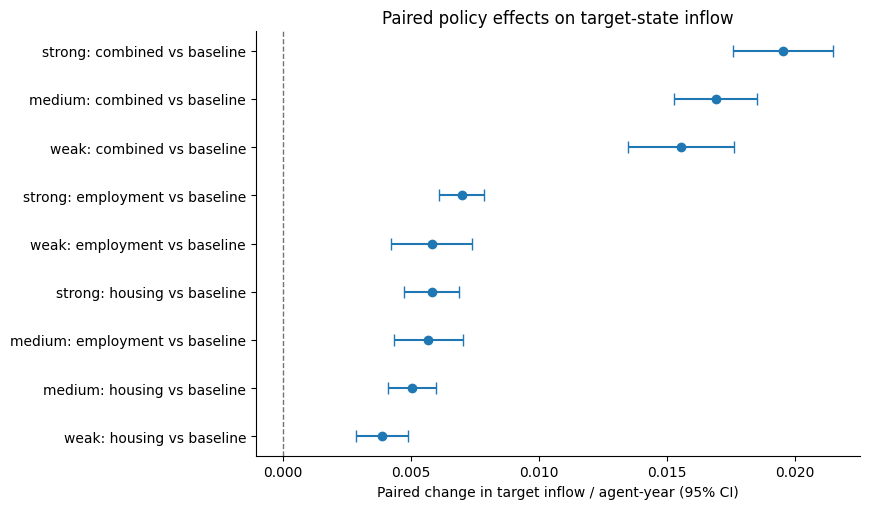

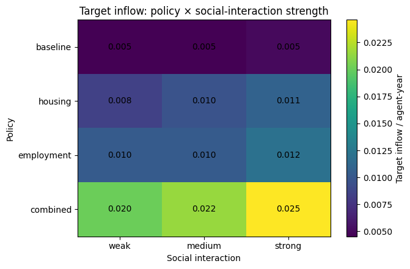

```python
# 1) Forest plot of paired target-inflow effects with 95% t intervals.
forest_rows = []
for (interaction, policy), g in policy_effects.groupby(["interaction", "policy"]):
    effect, ci = mean_t_ci(g["d_target_inflow_rate"])
    forest_rows.append({
        "comparison": f"{interaction}: {policy} vs baseline",
        "effect_mean": effect,
        "effect_ci95": ci,
    })
policy_effect_forest = pd.DataFrame(forest_rows).sort_values("effect_mean")

y = np.arange(len(policy_effect_forest))
fig, ax = plt.subplots(figsize=(8.8, 5.2))
ax.errorbar(
    policy_effect_forest["effect_mean"], y,
    xerr=policy_effect_forest["effect_ci95"],
    fmt="o", capsize=4,
)
ax.axvline(0, color="0.45", linestyle="--", linewidth=1)
ax.set_yticks(y)
ax.set_yticklabels(policy_effect_forest["comparison"])
ax.set_xlabel("Paired change in target inflow / agent-year (95% CI)")
ax.set_title("Paired policy effects on target-state inflow")
ax.spines[["top", "right"]].set_visible(False)
plt.tight_layout()
plt.show()

# 2) Policy × social-interaction heatmap.
policy_order = ["baseline", "housing", "employment", "combined"]
interaction_order = ["weak", "medium", "strong"]
pivot = (
    cross_summary.pivot(index="policy", columns="interaction", values="target_inflow_rate")
    .reindex(index=policy_order, columns=interaction_order)
)
fig, ax = plt.subplots(figsize=(6.8, 4.5))
im = ax.imshow(pivot.to_numpy(), aspect="auto")
ax.set_xticks(range(len(pivot.columns)), pivot.columns)
ax.set_yticks(range(len(pivot.index)), pivot.index)
for i in range(pivot.shape[0]):
    for j in range(pivot.shape[1]):
        ax.text(j, i, f"{pivot.iloc[i, j]:.3f}", ha="center", va="center")
fig.colorbar(im, ax=ax, label="Target inflow / agent-year")
ax.set_title("Target inflow: policy × social-interaction strength")
ax.set_xlabel("Social interaction")
ax.set_ylabel("Policy")
plt.tight_layout()
plt.show()
```

## 10. Policy intensity and conditional response thresholds

All intensity curves below are rebuilt with the new fitted parameters. Response90 is the first observed intensity attaining 90% of a seed's maximum gain over its baseline; it is conditional on the chosen grid. Steepest-interval ties use deterministic rounded slopes. Hill curves extrapolate beyond observed intensities and must not be treated as validated real-world saturation limits.

Fitted-profile combined response thresholds:

| interaction | response90_median | response90_q25 | response90_q75 | steepest_low_median | steepest_high_median | response90_median_grid0to4 |
| --- | --- | --- | --- | --- | --- | --- |
| medium | 3.5 | 3.5 | 3.5 | 1.5 | 2 | 3 |
| strong | 3.5 | 3.375 | 3.5 | 2 | 2.5 | 3 |
| weak | 4 | 3.5 | 4 | 1.5 | 2 | 3.5 |

### Sweep runner and run-level summary

The results build does not carry the original run-summary function, so it is reconstructed here from `PolicySocialABM.mechanism_history()` and `history`. The reconstruction was checked against the cached outputs: with the same seeds it reproduces the Section 9 cross-experiment table and the earlier Section 10 threshold table exactly. Two details were recovered in that check:

- `target_inflow_rate` = accepted target-state movers / system agent-years; `housing_rejection` is the **target-state** rejection rate (rejected / proposed moves into the target).
- In the cross experiment every single-lever policy carries a `0.5 × intensity` migration incentive, so the combined package carries `1.0 × intensity`. The single-lever sweep in 10.5 instead uses **pure** levers, so its intensity-1.0 slice is not the Section 9 table.

The model records target-state mechanism counts against the global `FOCAL_STATE`, so the runner temporarily switches that global when another target state is simulated (Section 10.6) and restores it afterwards. Results are read from `RESULT_CACHE` when present; otherwise the runner simulates them (serially this takes a long time).

```python
def summarise_v7_run(model, history, target_state):
    mech = model.mechanism_history()
    target = history[history["state"] == target_state]
    system = history.groupby("year").first()
    accepted = mech["target_accepted"].sum()
    return {
        "target_inflow_rate": accepted / history.groupby("year")["population"].sum().sum(),
        "target_social_cost": mech["target_social_cost_sum"].sum() / max(mech["target_social_cost_n"].sum(), 1),
        "chain_share": mech["target_chain_moves"].sum() / max(accepted, 1),
        "housing_rejection": mech["target_housing_rejected"].sum() / max(mech["target_proposed"].sum(), 1),
        "job_rejection": target["job_rejection_rate_state"].mean(),
        "coorigin_clustering": system["coorigin_clustering"].iloc[-1],
    }

def lever_policy(target_state, lever, intensity):
    if lever == "combined":  # original V7 package: housing + employment, each carrying a 0.5x incentive
        return policy_table(target_state, housing=intensity, employment=intensity, migration_incentive=intensity)
    return policy_table(target_state, **{lever: intensity})  # pure single lever, no bundled incentive

def run_lever_case(target_state, lever, intensity, interaction, seed):
    global FOCAL_STATE
    saved_focal = FOCAL_STATE
    FOCAL_STATE = target_state
    try:
        model = PolicySocialABM(
            state_data, lever_policy(target_state, lever, intensity), seed=seed,
            interaction_strength=INTERACTION_LEVELS[interaction],
        )
        history, _, _ = model.run()
        summary = summarise_v7_run(model, history, target_state)
    finally:
        FOCAL_STATE = saved_focal
    return {"target_state": target_state, "lever": lever, "intensity": intensity,
            "interaction": interaction, "seed": seed, **summary}

def cached_or_run(filename, cases):
    path = RESULT_CACHE / filename
    if path.exists():
        return pd.read_csv(path)
    runs = pd.DataFrame(run_cases(run_lever_case, cases))
    path.parent.mkdir(parents=True, exist_ok=True)
    runs.to_csv(path, index=False)
    return runs

def thresholds_by_seed(runs, group_cols, x_col="intensity", y="target_inflow_rate"):
    # Same definitions as Section 10: smallest intensity reaching 90% of the seed's
    # maximum gain over no policy, and the grid interval with the steepest slope.
    rows = []
    for keys, g in runs.groupby(group_cols + ["seed"]):
        g = g.sort_values(x_col)
        x, v = g[x_col].to_numpy(), g[y].to_numpy()
        gain = v - v[0]
        # Inflow rates are counts / agent-years, so equal slopes are exact ties. Rounding before argmax resolves a
        # tie to the lower interval regardless of how many digits the cached CSV kept (1e-16 noise otherwise decides).
        k = int(np.argmax(np.round(np.diff(v) / np.diff(x), 12)))
        rows.append({**dict(zip(group_cols + ["seed"], keys)),
                     "response90": x[np.argmax(gain >= 0.9 * gain.max() - 1e-12)] if gain.max() > 0 else np.nan,
                     "steepest_low": x[k], "steepest_high": x[k + 1]})
    return pd.DataFrame(rows)

def saturation_table(runs, group_cols):
    thr = thresholds_by_seed(runs, group_cols).groupby(group_cols).agg(
        response90_median=("response90", "median"),
        steepest_low_median=("steepest_low", "median"),
    )
    curve = runs.groupby(group_cols + ["intensity"])["target_inflow_rate"].mean().reset_index()
    fit_rows = []
    for keys, g in curve.groupby(group_cols):
        keys = keys if isinstance(keys, tuple) else (keys,)
        g = g.sort_values("intensity")
        base = float(g["target_inflow_rate"].iloc[0])
        row = dict(zip(group_cols, keys))
        row.update({"baseline": base,
                    "gain_at_1": float(g.loc[np.isclose(g["intensity"], 1.0), "target_inflow_rate"].iloc[0]) - base,
                    "gain_at_max": float(g["target_inflow_rate"].iloc[-1]) - base})
        try:
            y0, A, K, n = fit_hill(g["intensity"], g["target_inflow_rate"])
            row.update({"fitted_ceiling_gain": y0 + A - base, "half_response_K": K, "hill_n": n,
                        "share_of_ceiling_at_max": row["gain_at_max"] / (y0 + A - base) if y0 + A > base else np.nan})
        except RuntimeError:
            row.update({"fitted_ceiling_gain": np.nan, "half_response_K": np.nan, "hill_n": np.nan,
                        "share_of_ceiling_at_max": np.nan})
        fit_rows.append(row)
    return pd.DataFrame(fit_rows).merge(thr.reset_index(), on=group_cols)

# 0.5-unit grid to 4.0 (comparable with Section 10) plus 5 and 6 to detect
# saturation beyond the original range; all three social-tie levels.
EXTENDED_INTENSITIES = [float(x) for x in np.arange(0.0, 4.01, 0.5)] + [5.0, 6.0]
SWEEP_INTERACTIONS = ["weak", "medium", "strong"]
```

```python
LEVERS = ["housing", "employment", "migration_incentive", "combined"]
lever_cases = [(FOCAL_STATE, lever, x, inter, seed)
               for lever in LEVERS for x in EXTENDED_INTENSITIES
               for inter in SWEEP_INTERACTIONS for seed in SWEEP_SEEDS]
lever_runs = cached_or_run("lever_intensity_sweep_runs.csv", lever_cases)

POLICY_INTENSITIES = EXTENDED_INTENSITIES
sweep_runs = (lever_runs[lever_runs["lever"] == "combined"]
              .rename(columns={"intensity": "policy_intensity"}).reset_index(drop=True))
sweep_summary = sweep_runs.groupby(["interaction", "policy_intensity"]).agg(
    target_inflow_rate=("target_inflow_rate", "mean"),
    target_inflow_ci95=("target_inflow_rate", lambda s: mean_t_ci(s)[1]),
    target_social_cost=("target_social_cost", "mean"),
    chain_share=("chain_share", "mean"),
    housing_rejection=("housing_rejection", "mean"),
).reset_index()

threshold_by_seed = thresholds_by_seed(sweep_runs, ["interaction"], x_col="policy_intensity")
threshold_grid4 = thresholds_by_seed(sweep_runs[sweep_runs["policy_intensity"] <= 4.0], ["interaction"], x_col="policy_intensity")
threshold_summary = threshold_by_seed.groupby("interaction").agg(
    response90_median=("response90", "median"),
    response90_q25=("response90", lambda s: s.quantile(0.25)),
    response90_q75=("response90", lambda s: s.quantile(0.75)),
    steepest_low_median=("steepest_low", "median"),
    steepest_high_median=("steepest_high", "median"),
).join(threshold_grid4.groupby("interaction")["response90"].median().rename("response90_median_grid0to4")).reset_index()
display(threshold_summary.round(3))
```

|  | interaction | response90_median | response90_q25 | response90_q75 | steepest_low_median | steepest_high_median | response90_median_grid0to4 |
| --- | --- | --- | --- | --- | --- | --- | --- |
| 0 | medium | 3.5 | 3.500 | 3.5 | 1.5 | 2.0 | 3.0 |
| 1 | strong | 3.5 | 3.375 | 3.5 | 2.0 | 2.5 | 3.0 |
| 2 | weak | 4.0 | 3.500 | 4.0 | 1.5 | 2.0 | 3.5 |

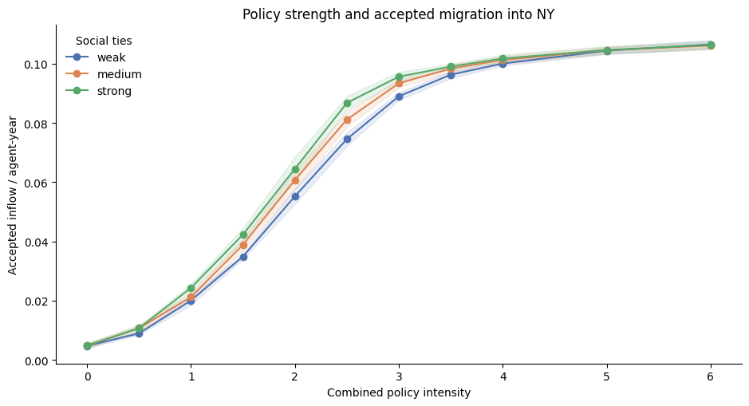

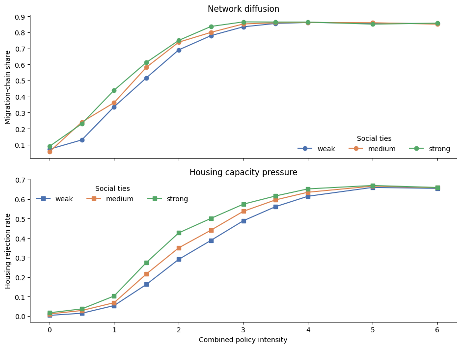

```python
# Main response curve with consistent social-interaction colors.
fig, ax = plt.subplots(figsize=(9.5, 5.2))
for label in ["weak", "medium", "strong"]:
    g = sweep_summary[sweep_summary["interaction"] == label].sort_values("policy_intensity")
    x = g["policy_intensity"].to_numpy()
    y = g["target_inflow_rate"].to_numpy()
    ci = g["target_inflow_ci95"].to_numpy()
    ax.plot(x, y, marker="o", color=INTERACTION_COLORS[label], label=label)
    ax.fill_between(x, y - ci, y + ci, color=INTERACTION_COLORS[label], alpha=0.12)
ax.set_title(f"Policy strength and accepted migration into {FOCAL_STATE}")
ax.set_xlabel("Combined policy intensity")
ax.set_ylabel("Accepted inflow / agent-year")
ax.legend(title="Social ties", frameon=False)
ax.spines[["top", "right"]].set_visible(False)
plt.tight_layout()
plt.show()

# Keep network diffusion and capacity pressure visually paired by color, but
# separate the metrics into two panels so line style is not doing too much work.
fig, axes = plt.subplots(2, 1, figsize=(9.5, 7.2), sharex=True)
for label in ["weak", "medium", "strong"]:
    g = sweep_summary[sweep_summary["interaction"] == label].sort_values("policy_intensity")
    axes[0].plot(
        g["policy_intensity"], g["chain_share"], marker="o",
        color=INTERACTION_COLORS[label], label=label,
    )
    axes[1].plot(
        g["policy_intensity"], g["housing_rejection"], marker="s",
        color=INTERACTION_COLORS[label], label=label,
    )
axes[0].set_title("Network diffusion")
axes[0].set_ylabel("Migration-chain share")
axes[1].set_title("Housing capacity pressure")
axes[1].set_xlabel("Combined policy intensity")
axes[1].set_ylabel("Housing rejection rate")
for ax in axes:
    ax.legend(title="Social ties", frameon=False, ncol=3)
    ax.spines[["top", "right"]].set_visible(False)
plt.tight_layout()
plt.show()
```

### 10.1 Tulsa Remote external-reference diagnostic

To make the policy scale interpretable without pretending that a remote-worker program is representative of all 18–35-year-olds, V7 adds a **reference-only** monetary mapping: one migration-incentive intensity unit is displayed as a `$10,000` equivalent because Tulsa Remote pays selected remote workers $10,000 to move and stay at least one year. Bartik (2025, Upjohn Institute Technical Report 25-050) estimates a 58–70% “but-for” share among Tulsa Remote member households.

The model is **not calibrated to this range**. Instead, a migration-incentive-only experiment reports the analogous simulated induced share `(policy inflow − baseline inflow) / policy inflow`. This is a diagnostic of scale and external plausibility only; population, geography, selection, and accompanying services differ substantially from Tulsa Remote.

Source: W.E. Upjohn Institute, Bartik (2025), *The Effects of Tulsa Remote on Inducing Moves to Tulsa: Estimates and Implications*, DOI 10.17848/tr25-050.

|  | reference_amount_usd | model_mean_induced_share | model_ci95_halfwidth | bartik_low | bartik_high | interpretation |
| --- | --- | --- | --- | --- | --- | --- |
| 0 | 10000 | 0.462 | 0.155 | 0.58 | 0.7 | external reference only; not calibration |

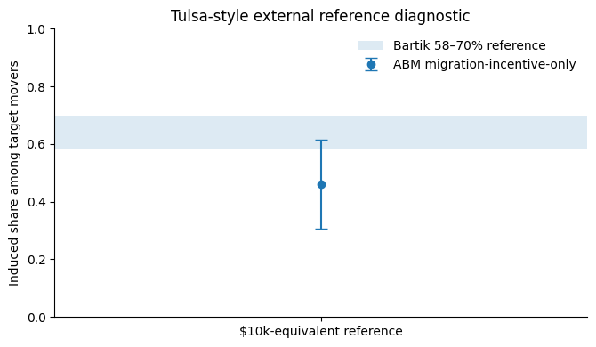

```python
TULSA_DOLLAR_PER_INTENSITY = 10_000
BARTIK_BUT_FOR_LOW = 0.58
BARTIK_BUT_FOR_HIGH = 0.70
def intensity_to_dollar_equivalent(intensity, dollar_per_unit=TULSA_DOLLAR_PER_INTENSITY):
    """Reference scale only; not a fiscal or causal calibration for general young adults."""
    return np.asarray(intensity, dtype=float) * float(dollar_per_unit)

cash_reference_runs = pd.read_csv(RESULT_CACHE / "tulsa_reference_runs.csv")
tulsa_reference_summary = pd.read_csv(RESULT_CACHE / "tulsa_reference_summary.csv")
tulsa_mean = float(tulsa_reference_summary.loc[0,"model_mean_induced_share"])
tulsa_ci = float(tulsa_reference_summary.loc[0,"model_ci95_halfwidth"])
display(tulsa_reference_summary.round(3))
fig, ax = plt.subplots(figsize=(6.8, 4.0))
ax.axhspan(BARTIK_BUT_FOR_LOW, BARTIK_BUT_FOR_HIGH, alpha=0.15, label="Bartik 58–70% reference")
ax.errorbar([0], [tulsa_mean], yerr=[tulsa_ci], fmt="o", capsize=5, label="ABM migration-incentive-only")
ax.set_xlim(-0.5, 0.5); ax.set_xticks([0], ["$10k-equivalent reference"])
ax.set_ylabel("Induced share among target movers")
ax.set_title("Tulsa-style external reference diagnostic")
ax.set_ylim(0, 1); ax.legend(frameon=False); ax.spines[["top","right"]].set_visible(False)
plt.tight_layout(); plt.show()
```

### 10.2 Saturation-curve fit: estimating the response ceiling

A finite grid cannot show where the response actually levels off. To estimate *where* the response levels off, a Hill saturation curve is fitted to the combined-package sweep, separately for each social-tie strength:

$$y(x) = y_0 + A\,\frac{x^n}{K^n + x^n}$$

`y0` is the no-policy inflow (the baseline is not zero, so it is kept as a free intercept), `y0 + A` is the fitted **response ceiling**, `K` is the half-response intensity, and `n` controls curvature. Uncertainty comes from a seed-level bootstrap on `sweep_runs`.

Reading the result: if the observed incremental gain at intensity 6.0 is already ≥95% of the fitted gain A, the grid has effectively reached the plateau. If not, or if `K` sits beyond the grid (the ceiling is then an extrapolation), the notebook flags that the sweep should be extended rather than treating the fitted ceiling as reliable.

**Verification clarification:** The current sweep extends to intensity 6.0; use share_of_gain_at_6 when discussing the endpoint plateau.

|  | interaction | baseline_y0 | fitted_ceiling | ceiling_ci_low | ceiling_ci_high | half_response_K | K_ci_low | K_ci_high | hill_n | intensity_90pct_gain | intensity_95pct_gain | share_of_gain_at_6 | n_bootstrap_fits | verdict |
| --- | --- | --- | --- | --- | --- | --- | --- | --- | --- | --- | --- | --- | --- | --- |
| 0 | weak | 0.0070 | 0.1109 | 0.1091 | 0.1125 | 2.0425 | 2.0015 | 2.0833 | 3.1565 | 4.0971 | 5.1914 | 0.9576 | 300 | plateau reached within grid |
| 1 | medium | 0.0078 | 0.1091 | 0.1078 | 0.1104 | 1.8941 | 1.8309 | 1.9466 | 3.3421 | 3.6553 | 4.5711 | 0.9704 | 300 | plateau reached within grid |
| 2 | strong | 0.0078 | 0.1088 | 0.1075 | 0.1102 | 1.7867 | 1.7373 | 1.8361 | 3.3061 | 3.4728 | 4.3535 | 0.9750 | 300 | plateau reached within grid |

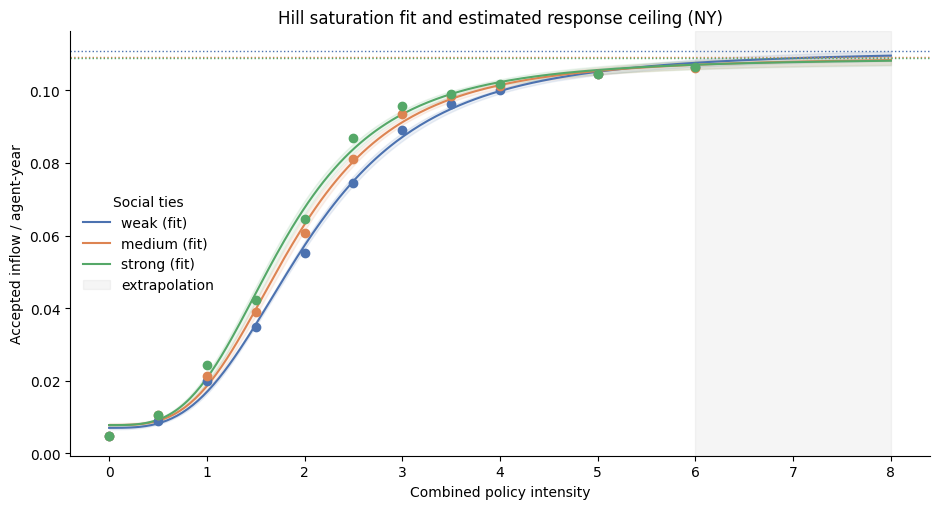

```python
from scipy.optimize import curve_fit

def hill_with_baseline(x, y0, A, K, n):
    x = np.asarray(x, dtype=float)
    return y0 + A * x**n / (K**n + x**n)

def fit_hill(x, y):
    x = np.asarray(x, dtype=float); y = np.asarray(y, dtype=float)
    y0_guess = float(y[np.argmin(x)])
    A_guess = max(float(y.max() - y0_guess), 1e-6)
    p0 = [y0_guess, A_guess, float(np.median(x[x > 0])), 2.0]
    bounds = ([-np.inf, 0.0, 1e-3, 0.3], [np.inf, 10 * max(abs(A_guess), 1e-3) + 1.0, 50.0, 8.0])
    popt, _ = curve_fit(hill_with_baseline, x, y, p0=p0, bounds=bounds, maxfev=20000)
    return popt

def _seed_col(df):
    for c in ["seed", "run_seed", "replicate", "rep"]:
        if c in df.columns:
            return c
    return None

HILL_BOOTSTRAP = 300
SWEEP_X_MAX = float(sweep_summary["policy_intensity"].max())
hill_rows, hill_boot = [], {}
rng_hill = np.random.default_rng(RANDOM_SEED)
seed_col = _seed_col(sweep_runs)

for label in ["weak", "medium", "strong"]:
    g = sweep_summary[sweep_summary["interaction"] == label].sort_values("policy_intensity")
    y0, A, K, n = fit_hill(g["policy_intensity"], g["target_inflow_rate"])
    ceiling = y0 + A
    observed_at_max = float(g["target_inflow_rate"].iloc[-1])
    gain_at_max = observed_at_max - y0
    # Bootstrap over seeds: resample seeds, rebuild the mean curve, refit.
    boot = []
    runs = sweep_runs[sweep_runs["interaction"] == label]
    if seed_col is not None and runs[seed_col].nunique() > 1:
        seeds = runs[seed_col].unique()
        for _ in range(HILL_BOOTSTRAP):
            pick = rng_hill.choice(seeds, size=len(seeds), replace=True)
            sample = pd.concat([runs[runs[seed_col] == s] for s in pick])
            curve = sample.groupby("policy_intensity")["target_inflow_rate"].mean()
            try:
                b = fit_hill(curve.index.to_numpy(), curve.to_numpy())
                boot.append(b)
            except RuntimeError:
                continue
    boot = np.array(boot)
    hill_boot[label] = boot
    ceiling_lo = ceiling_hi = K_lo = K_hi = np.nan
    if len(boot):
        ceiling_lo, ceiling_hi = np.percentile(boot[:, 0] + boot[:, 1], [2.5, 97.5])
        K_lo, K_hi = np.percentile(boot[:, 2], [2.5, 97.5])
    # Intensity at which the fitted curve reaches 90% / 95% of its gain A.
    x90 = K * (0.90 / 0.10) ** (1.0 / n)
    x95 = K * (0.95 / 0.05) ** (1.0 / n)
    share_reached = gain_at_max / A if A > 0 else np.nan
    if K > SWEEP_X_MAX:
        verdict = "ceiling extrapolated (K beyond grid) - extend sweep"
    elif share_reached >= 0.95:
        verdict = "plateau reached within grid"
    else:
        verdict = "still rising - extend sweep"
    hill_rows.append({
        "interaction": label, "baseline_y0": y0, "fitted_ceiling": ceiling,
        "ceiling_ci_low": ceiling_lo, "ceiling_ci_high": ceiling_hi,
        "half_response_K": K, "K_ci_low": K_lo, "K_ci_high": K_hi, "hill_n": n,
        "intensity_90pct_gain": x90, "intensity_95pct_gain": x95,
        f"share_of_gain_at_{SWEEP_X_MAX:g}": share_reached,
        "n_bootstrap_fits": len(boot), "verdict": verdict,
    })

hill_summary = pd.DataFrame(hill_rows)
display(hill_summary.round(4))

fig, ax = plt.subplots(figsize=(9.5, 5.2))
x_ext = np.linspace(0, max(8.0, SWEEP_X_MAX), 300)
for label in ["weak", "medium", "strong"]:
    g = sweep_summary[sweep_summary["interaction"] == label].sort_values("policy_intensity")
    row = hill_summary.set_index("interaction").loc[label]
    params = row[["baseline_y0", "fitted_ceiling", "half_response_K", "hill_n"]].to_numpy(dtype=float)
    params[1] = params[1] - params[0]  # ceiling -> A
    color = INTERACTION_COLORS[label]
    ax.scatter(g["policy_intensity"], g["target_inflow_rate"], color=color, zorder=3)
    ax.plot(x_ext, hill_with_baseline(x_ext, *params), color=color, label=f"{label} (fit)")
    ax.axhline(row["fitted_ceiling"], color=color, linestyle=":", linewidth=1)
    boot = hill_boot[label]
    if len(boot):
        band = np.array([hill_with_baseline(x_ext, *b) for b in boot])
        lo, hi = np.percentile(band, [2.5, 97.5], axis=0)
        ax.fill_between(x_ext, lo, hi, color=color, alpha=0.10)
ax.axvspan(SWEEP_X_MAX, x_ext.max(), color="grey", alpha=0.08, label="extrapolation")
ax.set_xlabel("Combined policy intensity")
ax.set_ylabel("Accepted inflow / agent-year")
ax.set_title(f"Hill saturation fit and estimated response ceiling ({FOCAL_STATE})")
ax.legend(title="Social ties", frameon=False)
ax.spines[["top", "right"]].set_visible(False)
plt.tight_layout(); plt.show()
```

### 10.3 Cost reference

One intensity unit is illustrated as $10,000 per accepted mover, an external Tulsa cash-programme reference. Total spending pays all accepted movers; marginal cost is the change in spending divided by the change in accepted inflow. The table recomputes these quantities using the new results. Rising per-mover payments mechanically raise marginal cost, so a cost kink is not independent evidence of response saturation.

```python
COST_KINK_MULTIPLE = 2.0

cost_curve = sweep_summary.sort_values(["interaction", "policy_intensity"]).copy()
cost_curve["dollar_per_mover"] = intensity_to_dollar_equivalent(cost_curve["policy_intensity"])
cost_curve["total_spend_per_agent_year"] = cost_curve["dollar_per_mover"] * cost_curve["target_inflow_rate"]
baseline_inflow = (
    cost_curve[cost_curve["policy_intensity"] == 0]
    .set_index("interaction")["target_inflow_rate"]
)
cost_curve["baseline_inflow"] = cost_curve["interaction"].map(baseline_inflow)
cost_curve["induced_inflow"] = cost_curve["target_inflow_rate"] - cost_curve["baseline_inflow"]
cost_curve["avg_cost_per_induced_mover"] = np.where(
    cost_curve["induced_inflow"] > 0,
    cost_curve["total_spend_per_agent_year"] / cost_curve["induced_inflow"], np.nan,
)
grp = cost_curve.groupby("interaction")
cost_curve["marginal_inflow"] = grp["target_inflow_rate"].diff()
cost_curve["marginal_spend"] = grp["total_spend_per_agent_year"].diff()
cost_curve["marginal_cost_per_additional_mover"] = np.where(
    cost_curve["marginal_inflow"] > 0,
    cost_curve["marginal_spend"] / cost_curve["marginal_inflow"], np.inf,
)
cost_curve.loc[cost_curve["marginal_inflow"].isna(), "marginal_cost_per_additional_mover"] = np.nan

kink_rows = []
for label, g in cost_curve.groupby("interaction"):
    mc = g.dropna(subset=["marginal_cost_per_additional_mover"])
    first_mc = mc["marginal_cost_per_additional_mover"].iloc[0]
    over = mc[mc["marginal_cost_per_additional_mover"] > COST_KINK_MULTIPLE * first_mc]
    kink = float(over["policy_intensity"].iloc[0]) if len(over) else np.nan
    resp90 = threshold_summary.set_index("interaction").loc[label, "response90_median"]
    kink_rows.append({
        "interaction": label,
        "first_step_marginal_cost": first_mc,
        f"cost_kink_intensity_{COST_KINK_MULTIPLE:g}x": kink,
        "cost_kink_dollars_per_mover": intensity_to_dollar_equivalent(kink) if np.isfinite(kink) else np.nan,
        "response90_median": resp90,
        "kink_before_response90": bool(np.isfinite(kink) and kink < resp90),
    })
cost_kink_summary = pd.DataFrame(kink_rows)

display(cost_kink_summary.round(3))
display(cost_curve.pivot(index="policy_intensity", columns="interaction", values="marginal_cost_per_additional_mover")
        .reindex(columns=["weak", "medium", "strong"]).round(0)
        .rename_axis(columns="marginal USD per extra mover"))
```

|  | interaction | first_step_marginal_cost | cost_kink_intensity_2x | cost_kink_dollars_per_mover | response90_median | kink_before_response90 |
| --- | --- | --- | --- | --- | --- | --- |
| 0 | medium | 9029.412 | 1.5 | 15000.0 | 3.5 | True |
| 1 | strong | 9136.905 | 1.5 | 15000.0 | 3.5 | True |
| 2 | weak | 10578.512 | 1.5 | 15000.0 | 4.0 | True |

| marginal USD per extra mover policy_intensity | weak | medium | strong |
| --- | --- | --- | --- |
| 0.0 | NaN | NaN | NaN |
| 0.5 | 10579.0 | 9029.0 | 9137.0 |
| 1.0 | 13994.0 | 15041.0 | 13916.0 |
| 1.5 | 21735.0 | 21037.0 | 21741.0 |
| 2.0 | 28578.0 | 28859.0 | 29527.0 |
| 2.5 | 39299.0 | 39885.0 | 39459.0 |
| 3.0 | 55762.0 | 63142.0 | 78990.0 |
| 3.5 | 95867.0 | 128693.0 | 175485.0 |
| 4.0 | 168380.0 | 210633.0 | 220475.0 |
| 5.0 | 280480.0 | 353698.0 | 407378.0 |
| 6.0 | 552787.0 | 736742.0 | 674796.0 |

### 10.4 Side-effect-weighted optimum

This illustrative index subtracts weighted, min–max-scaled social cost and housing rejection from inflow. Its weights are assumptions. The table recomputes the optimum and interior-optimum share over the stated weight grid using the new results; an optimum conditional on these weights is not a validated policy recommendation.

Weight sensitivity of the fitted-profile optimum:

| interaction | min | median | max | share_interior | optimum_at_0.5_0.3 |
| --- | --- | --- | --- | --- | --- |
| medium | 0 | 1 | 6 | 0.2 | 6 |
| strong | 0 | 1 | 6 | 0.2 | 6 |
| weak | 0 | 1 | 6 | 0.44 | 6 |

```python
NET_W_SOCIAL, NET_W_HOUSING = 0.5, 0.3
W_SOCIAL_GRID = [0.0, 0.25, 0.5, 1.0, 2.0]
W_HOUSING_GRID = [0.0, 0.15, 0.3, 0.6, 1.2]

net_df = sweep_summary.sort_values(["interaction", "policy_intensity"]).copy()
if "target_social_cost" not in net_df.columns:
    social = (
        sweep_runs.groupby(["interaction", "policy_intensity"])["target_social_cost"].mean()
        .rename("target_social_cost").reset_index()
    )
    net_df = net_df.merge(social, on=["interaction", "policy_intensity"], how="left")

def _minmax(s):
    rng = s.max() - s.min()
    return (s - s.min()) / rng if rng > 0 else s * 0.0

g = net_df.groupby("interaction")
net_df["inflow_scaled"] = g["target_inflow_rate"].transform(_minmax)
net_df["social_cost_scaled"] = g["target_social_cost"].transform(lambda s: _minmax(s.abs()))
net_df["housing_rejection_scaled"] = g["housing_rejection"].transform(_minmax)

def net_benefit(df, w_s, w_h):
    return df["inflow_scaled"] - w_s * df["social_cost_scaled"] - w_h * df["housing_rejection_scaled"]

net_df["net_benefit"] = net_benefit(net_df, NET_W_SOCIAL, NET_W_HOUSING)
x_max = net_df["policy_intensity"].max()
optimal_intensity = net_df.loc[net_df.groupby("interaction")["net_benefit"].idxmax(), ["interaction", "policy_intensity"]]

# Weight sensitivity: where does the optimum sit across the weight grid?
sens_rows = []
for w_s in W_SOCIAL_GRID:
    for w_h in W_HOUSING_GRID:
        tmp = net_df.assign(nb=net_benefit(net_df, w_s, w_h))
        for label, gg in tmp.groupby("interaction"):
            sens_rows.append({"interaction": label, "w_social": w_s, "w_housing": w_h,
                              "optimal_intensity": float(gg.loc[gg["nb"].idxmax(), "policy_intensity"])})
weight_sensitivity = pd.DataFrame(sens_rows)
robustness = weight_sensitivity.groupby("interaction")["optimal_intensity"].agg(
    min="min", median="median", max="max",
    share_interior=lambda s: float(((s > 0) & (s < x_max)).mean()),
).reset_index()
robustness = robustness.merge(optimal_intensity.rename(columns={"policy_intensity": f"optimum_at_{NET_W_SOCIAL}_{NET_W_HOUSING}"}), on="interaction")
display(robustness.round(3))
```

|  | interaction | min | median | max | share_interior | optimum_at_0.5_0.3 |
| --- | --- | --- | --- | --- | --- | --- |
| 0 | medium | 0.0 | 1.0 | 6.0 | 0.20 | 6.0 |
| 1 | strong | 0.0 | 1.0 | 6.0 | 0.20 | 6.0 |
| 2 | weak | 0.0 | 1.0 | 6.0 | 0.44 | 6.0 |

### 10.5 Single-lever saturation: which lever caps out first?

Section 10 sweeps only the combined package; housing-only and employment-only are measured at a single intensity (1.0). Here each lever is swept **on its own** from 0 to 6 in the focal state (0.5-unit steps to 4, then 5 and 6; all three social-tie levels): `housing`, `employment` and `migration_incentive` are pure single levers (no bundled incentive), and the original `combined` package is included as the reference curve. The grid is extended to 6 so that a lever still rising at 4 is not mistaken for one that has saturated.

The question is not only "how strong" but "which lever should be raised first and which still has headroom". A lever whose target-state housing rejection climbs while its inflow flattens is hitting the capacity wall; a lever that keeps adding inflow at low rejection still has room.

|  | lever | interaction | baseline | gain_at_1 | gain_at_max | fitted_ceiling_gain | half_response_K | hill_n | share_of_ceiling_at_max | response90_median | steepest_low_median |
| --- | --- | --- | --- | --- | --- | --- | --- | --- | --- | --- | --- |
| 0 | combined | medium | 0.0048 | 0.0165 | 0.1014 | 0.1044 | 1.8941 | 3.3421 | 0.9712 | 3.5 | 1.5 |
| 3 | employment | medium | 0.0048 | 0.0031 | 0.0151 | 0.0173 | 2.2028 | 1.6888 | 0.8688 | 5.0 | 1.0 |
| 6 | housing | medium | 0.0048 | 0.0021 | 0.0335 | 1.3358 | 35.5068 | 2.0885 | 0.0251 | 6.0 | 5.0 |
| 9 | migration_incentive | medium | 0.0048 | 0.0033 | 0.0163 | 0.0189 | 2.3415 | 1.7894 | 0.8600 | 5.5 | 1.5 |
| 1 | combined | strong | 0.0048 | 0.0194 | 0.1015 | 0.1040 | 1.7867 | 3.3061 | 0.9758 | 3.5 | 2.0 |
| 4 | employment | strong | 0.0048 | 0.0040 | 0.0153 | 0.0185 | 2.1573 | 1.4788 | 0.8277 | 5.0 | 1.0 |
| 7 | housing | strong | 0.0048 | 0.0026 | 0.0424 | 1.4242 | 32.0275 | 2.0975 | 0.0298 | 6.0 | 5.0 |
| 10 | migration_incentive | strong | 0.0048 | 0.0038 | 0.0161 | 0.0182 | 2.0360 | 1.7226 | 0.8838 | 5.0 | 1.0 |
| 2 | combined | weak | 0.0047 | 0.0153 | 0.1018 | 0.1062 | 2.0425 | 3.1565 | 0.9585 | 4.0 | 1.5 |
| 5 | employment | weak | 0.0047 | 0.0031 | 0.0146 | 0.0175 | 2.3398 | 1.7096 | 0.8347 | 5.0 | 1.0 |
| 8 | housing | weak | 0.0047 | 0.0013 | 0.0263 | 1.2635 | 44.1869 | 1.9439 | 0.0208 | 6.0 | 3.5 |
| 11 | migration_incentive | weak | 0.0047 | 0.0030 | 0.0160 | 0.0198 | 2.7125 | 1.7351 | 0.8107 | 5.5 | 1.0 |

| gain at 6 lever | weak | medium | strong |
| --- | --- | --- | --- |
| combined | 0.1018 | 0.1014 | 0.1015 |
| employment | 0.0146 | 0.0151 | 0.0153 |
| housing | 0.0263 | 0.0335 | 0.0424 |
| migration_incentive | 0.0160 | 0.0163 | 0.0161 |

| response90 (6 = censored) lever | weak | medium | strong |
| --- | --- | --- | --- |
| combined | 4.0 | 3.5 | 3.5 |
| employment | 5.0 | 5.0 | 5.0 |
| housing | 6.0 | 6.0 | 6.0 |
| migration_incentive | 5.5 | 5.5 | 5.0 |

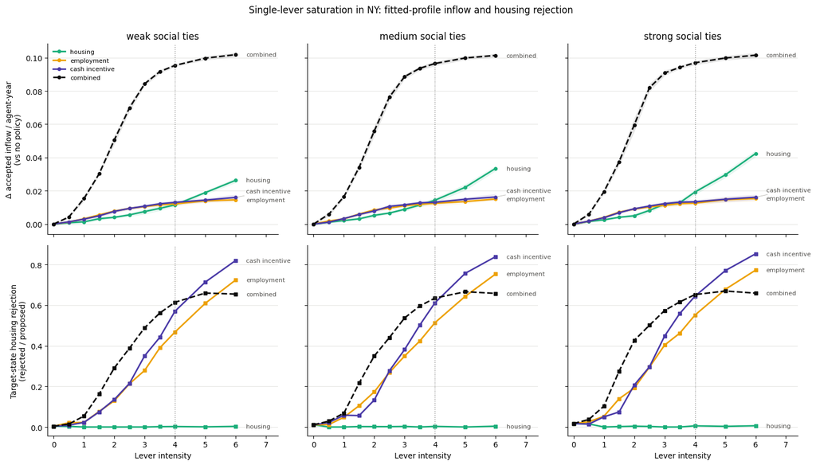

```python
LEVER_STYLES = {
    "housing": {"color": "#1baf7a"}, "employment": {"color": "#eda100"},
    "migration_incentive": {"color": "#4a3aa7"}, "combined": {"color": "#0b0b0b", "linestyle": "--"},
}
LEVER_LABELS = {"housing": "housing", "employment": "employment", "migration_incentive": "cash incentive", "combined": "combined"}

def spread_labels(ax, items, x, min_gap_frac=0.045):
    # Direct-label line ends at x, nudging labels apart vertically so they never overlap.
    lo, hi = ax.get_ylim(); gap = (hi - lo) * min_gap_frac
    placed = []
    for y, text in sorted(items):
        placed.append([max(y, placed[-1][0] + gap) if placed else y, y, text])
    overflow = placed[-1][0] - (hi - gap / 2)
    if overflow > 0:
        for p in placed:
            p[0] -= overflow
    for y_text, y_line, text in placed:
        moved = abs(y_text - y_line) > gap / 4
        ax.annotate(text, (x, y_line), xytext=(x + 0.35, y_text), textcoords="data", va="center",
                    fontsize=8, color="#52514e", annotation_clip=False,
                    arrowprops=dict(arrowstyle="-", color="#b5b4ae", lw=0.6) if moved else None)

lever_summary = lever_runs.groupby(["lever", "interaction", "intensity"]).agg(
    target_inflow_rate=("target_inflow_rate", "mean"),
    target_inflow_ci95=("target_inflow_rate", lambda s: mean_t_ci(s)[1]),
    housing_rejection=("housing_rejection", "mean"),
    job_rejection=("job_rejection", "mean"),
    chain_share=("chain_share", "mean"),
).reset_index()
lever_saturation = saturation_table(lever_runs, ["lever", "interaction"])
display(lever_saturation.sort_values(["interaction", "lever"]).round(4))
display(lever_saturation.pivot(index="lever", columns="interaction", values="gain_at_max")
        .reindex(columns=SWEEP_INTERACTIONS).round(4).rename_axis(columns=f"gain at {max(EXTENDED_INTENSITIES):g}"))
display(lever_saturation.pivot(index="lever", columns="interaction", values="response90_median")
        .reindex(columns=SWEEP_INTERACTIONS).rename_axis(columns="response90 (6 = censored)"))

# Row 1: inflow gain; row 2: target-state housing rejection; one column per tie level.
fig, axes = plt.subplots(2, 3, figsize=(15.0, 8.4), sharex=True, sharey="row")
ends = {}
for j, inter in enumerate(SWEEP_INTERACTIONS):
    for lever in LEVERS:
        g = lever_summary[(lever_summary["lever"] == lever) & (lever_summary["interaction"] == inter)]
        base = g["target_inflow_rate"].iloc[0]
        style = LEVER_STYLES[lever]
        gain = g["target_inflow_rate"] - base
        axes[0, j].plot(g["intensity"], gain, marker="o", ms=4, lw=2, label=LEVER_LABELS[lever], **style)
        axes[0, j].fill_between(g["intensity"], gain - g["target_inflow_ci95"], gain + g["target_inflow_ci95"],
                                color=style["color"], alpha=0.10, lw=0)
        axes[1, j].plot(g["intensity"], g["housing_rejection"], marker="s", ms=4, lw=2, label=LEVER_LABELS[lever], **style)
        ends.setdefault((0, j), []).append((gain.iloc[-1], LEVER_LABELS[lever]))
        ends.setdefault((1, j), []).append((g["housing_rejection"].iloc[-1], LEVER_LABELS[lever]))
    axes[0, j].set_title(f"{inter} social ties")
    axes[1, j].set_xlabel("Lever intensity")
for ax in axes.ravel():
    ax.axvline(4.0, color="#8c8c8c", linestyle=":", linewidth=1)
    ax.set_xlim(-0.2, 7.4)
    ax.grid(axis="y", color="#e6e6e3", linewidth=0.8); ax.set_axisbelow(True)
    ax.spines[["top", "right"]].set_visible(False)
axes[0, 0].set_ylabel("Δ accepted inflow / agent-year\n(vs no policy)")
axes[1, 0].set_ylabel("Target-state housing rejection\n(rejected / proposed)")
axes[0, 0].legend(frameon=False, fontsize=8, loc="upper left")
for (r, j), items in ends.items():
    spread_labels(axes[r, j], items, max(EXTENDED_INTENSITIES))
fig.suptitle(f"Single-lever saturation in {FOCAL_STATE}: fitted-profile inflow and housing rejection", y=1.0)
plt.tight_layout(); plt.show()
```

### 10.6 Target-state heterogeneity: is the saturation point the same everywhere?

|  | target_state | interaction | baseline | gain_at_1 | gain_at_max | fitted_ceiling_gain | half_response_K | hill_n | share_of_ceiling_at_max | response90_median | steepest_low_median | housing_capacity_index | rent_index | vacancy_rate | youth_pop_weight | gain_relative_to_baseline | housing_rejection_at_max |
| --- | --- | --- | --- | --- | --- | --- | --- | --- | --- | --- | --- | --- | --- | --- | --- | --- | --- |
| 0 | CA | medium | 0.0069 | 0.0245 | 0.0868 | 0.0877 | 1.3897 | 3.1083 | 0.9895 | 3.0 | 1.0 | 0.7684 | 1.2592 | 0.0720 | 2.1471 | 12.6506 | 0.5066 |
| 3 | FL | medium | 0.0080 | 0.0278 | 0.0993 | 0.1004 | 1.4117 | 2.9570 | 0.9889 | 3.0 | 1.0 | 1.5170 | 1.0866 | 0.1421 | 1.0782 | 12.4100 | 0.6253 |
| 18 | TX | medium | 0.0066 | 0.0256 | 0.0924 | 0.0932 | 1.3848 | 3.0460 | 0.9919 | 3.0 | 1.0 | 0.9767 | 0.8932 | 0.0915 | 1.7002 | 13.9738 | 0.5583 |
| 15 | NY | medium | 0.0048 | 0.0165 | 0.1014 | 0.1044 | 1.8941 | 3.3421 | 0.9712 | 3.5 | 1.5 | 1.0165 | 0.9867 | 0.0952 | 1.0368 | 21.3066 | 0.6582 |
| 12 | NC | medium | 0.0033 | 0.0121 | 0.1051 | 0.1104 | 2.3057 | 3.5374 | 0.9520 | 4.0 | 2.5 | 1.2573 | 0.7870 | 0.1178 | 0.5722 | 32.2128 | 0.7259 |
| 6 | IL | medium | 0.0032 | 0.0103 | 0.1037 | 0.1098 | 2.4973 | 3.7373 | 0.9443 | 4.0 | 2.5 | 0.7794 | 0.7826 | 0.0730 | 0.6546 | 31.9305 | 0.7175 |
| 9 | MA | medium | 0.0028 | 0.0087 | 0.1035 | 0.1147 | 3.0892 | 3.7279 | 0.9019 | 5.0 | 3.0 | 0.8582 | 1.1106 | 0.0804 | 0.3831 | 37.0248 | 0.7750 |
| 21 | WA | medium | 0.0028 | 0.0085 | 0.1035 | 0.1119 | 2.9223 | 3.9444 | 0.9244 | 5.0 | 3.0 | 0.8265 | 1.0942 | 0.0774 | 0.4279 | 36.3354 | 0.7727 |

| response90 target_state | weak | medium | strong |
| --- | --- | --- | --- |
| CA | 3.0 | 3.0 | 3.00 |
| FL | 3.5 | 3.0 | 3.00 |
| TX | 3.5 | 3.0 | 2.50 |
| NY | 4.0 | 3.5 | 3.50 |
| NC | 4.0 | 4.0 | 3.75 |
| IL | 4.0 | 4.0 | 4.00 |
| MA | 5.0 | 5.0 | 4.50 |
| WA | 5.0 | 5.0 | 5.00 |

| outcome | interaction state_feature | weak | medium | strong |
| --- | --- | --- | --- | --- |
| gain_at_max | housing_capacity_index | 0.14 | 0.14 | 0.19 |
|  | rent_index | -0.52 | -0.52 | -0.38 |
|  | vacancy_rate | 0.14 | 0.14 | 0.19 |
|  | youth_pop_weight | -0.81 | -0.81 | -0.88 |
| housing_rejection_at_max | housing_capacity_index | 0.05 | 0.05 | 0.05 |
|  | rent_index | -0.05 | -0.05 | -0.05 |
|  | vacancy_rate | 0.05 | 0.05 | 0.05 |
|  | youth_pop_weight | -1.00 | -1.00 | -1.00 |
| response90_median | housing_capacity_index | -0.02 | -0.20 | -0.28 |
|  | rent_index | -0.04 | 0.00 | 0.06 |
|  | vacancy_rate | -0.02 | -0.20 | -0.28 |
|  | youth_pop_weight | -0.96 | -0.96 | -0.91 |

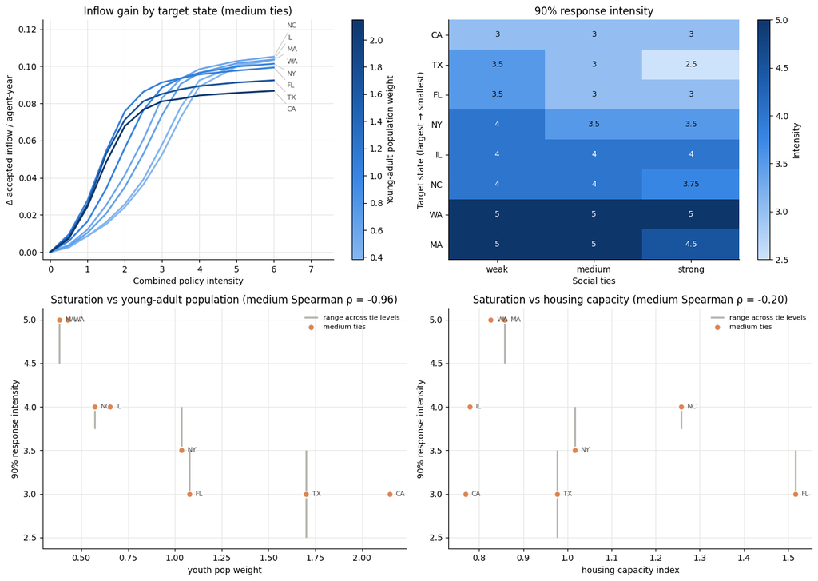

```python
state_cases = [(state, "combined", x, inter, seed)
               for state in STATE_CODES for x in EXTENDED_INTENSITIES
               for inter in SWEEP_INTERACTIONS for seed in SWEEP_SEEDS]
state_runs = cached_or_run("state_intensity_sweep_runs.csv", state_cases)
state_saturation = saturation_table(state_runs, ["target_state", "interaction"])
state_saturation = state_saturation.merge(
    state_data[["housing_capacity_index", "rent_index", "vacancy_rate", "youth_pop_weight"]],
    left_on="target_state", right_index=True,
)
state_saturation["gain_relative_to_baseline"] = state_saturation["gain_at_max"] / state_saturation["baseline"]
state_rejection = (state_runs[state_runs["intensity"] == max(EXTENDED_INTENSITIES)]
                   .groupby(["target_state", "interaction"])["housing_rejection"].mean()
                   .rename("housing_rejection_at_max").reset_index())
state_saturation = state_saturation.merge(state_rejection, on=["target_state", "interaction"])
display(state_saturation[state_saturation["interaction"] == "medium"]
        .sort_values("response90_median").round(4))
display(state_saturation.pivot(index="target_state", columns="interaction", values="response90_median")
        .reindex(columns=SWEEP_INTERACTIONS).sort_values("medium").rename_axis(columns="response90"))

from scipy.stats import spearmanr
corr_rows = []
for inter, gi in state_saturation.groupby("interaction"):
    for col in ["housing_capacity_index", "rent_index", "vacancy_rate", "youth_pop_weight"]:
        for outcome in ["response90_median", "gain_at_max", "housing_rejection_at_max"]:
            rho, p = spearmanr(gi[col], gi[outcome])
            corr_rows.append({"interaction": inter, "state_feature": col, "outcome": outcome, "spearman_rho": rho, "p_value": p})
state_correlations = pd.DataFrame(corr_rows)
display(state_correlations.pivot_table(index=["outcome", "state_feature"], columns="interaction", values="spearman_rho")
        .reindex(columns=SWEEP_INTERACTIONS).round(2))
med = state_saturation[state_saturation["interaction"] == "medium"].set_index("target_state")

from matplotlib.colors import LinearSegmentedColormap, Normalize
SEQ_BLUE = LinearSegmentedColormap.from_list("seq_blue", ["#cde2fb", "#86b6ef", "#3987e5", "#1c5cab", "#0d366b"])
pop = state_data["youth_pop_weight"]
line_norm = Normalize(pop.min(), pop.max())
line_cmap = LinearSegmentedColormap.from_list("seq_blue_lines", ["#86b6ef", "#3987e5", "#1c5cab", "#0d366b"])

state_curves = state_runs[state_runs["interaction"] == "medium"].groupby(["target_state", "intensity"])["target_inflow_rate"].mean().reset_index()
fig, axes = plt.subplots(2, 2, figsize=(13.5, 9.6))
ax = axes[0, 0]
state_ends = []
for state in pop.sort_values().index:
    g = state_curves[state_curves["target_state"] == state]
    gain = g["target_inflow_rate"] - g["target_inflow_rate"].iloc[0]
    ax.plot(g["intensity"], gain, lw=2, color=line_cmap(line_norm(pop[state])))
    state_ends.append((gain.iloc[-1], state))
ax.set_xlim(-0.2, 7.6); ax.set_ylim(-0.004, 0.125)
spread_labels(ax, state_ends, max(EXTENDED_INTENSITIES), min_gap_frac=0.05)
sm = plt.cm.ScalarMappable(norm=line_norm, cmap=line_cmap)
fig.colorbar(sm, ax=ax, label="Young-adult population weight")
ax.set_title("Inflow gain by target state (medium ties)")
ax.set_xlabel("Combined policy intensity"); ax.set_ylabel("Δ accepted inflow / agent-year")

ax = axes[0, 1]
heat = state_saturation.pivot(index="target_state", columns="interaction", values="response90_median").reindex(columns=SWEEP_INTERACTIONS)
heat = heat.loc[pop.sort_values(ascending=False).index]
im = ax.imshow(heat.to_numpy(), aspect="auto", cmap=SEQ_BLUE, vmin=2.5, vmax=5.0)
ax.set_xticks(range(heat.shape[1]), heat.columns); ax.set_yticks(range(heat.shape[0]), heat.index)
for i in range(heat.shape[0]):
    for j in range(heat.shape[1]):
        v = heat.iloc[i, j]
        ax.text(j, i, f"{v:g}", ha="center", va="center", fontsize=9, color="#ffffff" if v >= 4.0 else "#0b0b0b")
ax.set_xlabel("Social ties"); ax.set_ylabel("Target state (largest → smallest)")
ax.set_title("90% response intensity"); fig.colorbar(im, ax=ax, label="Intensity")

for ax, feature, title in [
    (axes[1, 0], "youth_pop_weight", "Saturation vs young-adult population"),
    (axes[1, 1], "housing_capacity_index", "Saturation vs housing capacity"),
]:
    # One point per state (medium ties); the vertical bar spans the strong-to-weak range.
    rng_ties = state_saturation.groupby("target_state")["response90_median"].agg(["min", "max"])
    med_i = state_saturation[state_saturation["interaction"] == "medium"].set_index("target_state")
    ax.vlines(med_i[feature], rng_ties.loc[med_i.index, "min"], rng_ties.loc[med_i.index, "max"],
              color="#b5b4ae", linewidth=2, label="range across tie levels", zorder=2)
    ax.scatter(med_i[feature], med_i["response90_median"], s=56, color=INTERACTION_COLORS["medium"],
               edgecolor="#fcfcfb", linewidth=1.5, label="medium ties", zorder=3)
    for state, r in med_i.iterrows():
        ax.annotate(state, (r[feature], r["response90_median"]), xytext=(7, 0),
                    textcoords="offset points", va="center", fontsize=8, color="#52514e")
    rho = state_correlations.query("interaction == 'medium' and state_feature == @feature and outcome == 'response90_median'")["spearman_rho"].iloc[0]
    ax.set_title(f"{title} (medium Spearman ρ = {rho:+.2f})")
    ax.set_xlabel(feature.replace("_", " ")); ax.set_ylabel("90% response intensity")
    ax.legend(frameon=False, fontsize=8)
for ax in axes.ravel():
    ax.spines[["top", "right"]].set_visible(False)
for ax in [axes[0, 0], axes[1, 0], axes[1, 1]]:
    ax.grid(color="#e6e6e3", linewidth=0.8); ax.set_axisbelow(True)
plt.tight_layout(); plt.show()
```

## 11. Shock and entrant robustness

Shock and entrant experiments use the separately validated 600-agent, 15-year stay parameter. Shocks, entrant placement and social-network initialization remain scenario assumptions. All rates and comparisons below come from fresh fitted-profile runs.

Regenerated scenario results (annual move rate; mean unfilled jobs):

- baseline: 3.8611%; 0.2556.
- financial_crisis: 4.4019%; 0.1778.
- labor_shortage: 3.7111%; 21.4111.
- pandemic: 4.0778%; 0.2000.

These comparisons describe the declared shocks; no causal effect or future forecast is claimed.

```python
SHOCK_NAMES = ["baseline", "financial_crisis", "pandemic", "labor_shortage"]
shock_runs = pd.read_csv(RESULT_CACHE / "shock_runs.csv")
shock_summary = pd.read_csv(RESULT_CACHE / "shock_summary.csv")
display(shock_summary.round(3))
```

|  | shock | move_rate | clustering | housing_rejection | social_utility_index | unfilled_jobs |
| --- | --- | --- | --- | --- | --- | --- |
| 0 | baseline | 0.039 | 0.171 | 0.029 | 0.344 | 0.256 |
| 1 | financial_crisis | 0.044 | 0.173 | 0.031 | 0.344 | 0.178 |
| 2 | labor_shortage | 0.037 | 0.175 | 0.023 | 0.344 | 21.411 |
| 3 | pandemic | 0.041 | 0.173 | 0.023 | 0.344 | 0.200 |

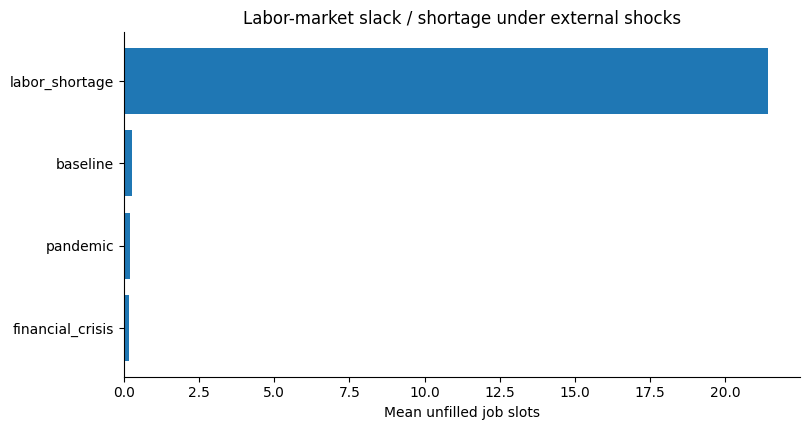

```python
fig, ax = plt.subplots(figsize=(8.2, 4.4))
g = shock_summary.sort_values("unfilled_jobs")
ax.barh(g["shock"], g["unfilled_jobs"])
ax.set_xlabel("Mean unfilled job slots")
ax.set_title("Labor-market slack / shortage under external shocks")
ax.spines[["top","right"]].set_visible(False)
plt.tight_layout(); plt.show()
```

## 12. Static state competition

The restored competition generator assigns incentives from a normalized score averaging inverse job index and housing capacity, mapped to [0.25, 1.0]. This is an explicit scenario rule, not strategic optimization by states. Six fitted-profile runs use seeds 401–406. Net migration, employment and state-level unfilled jobs are recomputed.

Fitted-profile final-year net migration:

| state | mean_net_migration | mean_employment | mean_unfilled_jobs |
| --- | --- | --- | --- |
| CA | -0.333333 | 0.797795 | 0 |
| FL | 5.83333 | 0.802403 | 0 |
| IL | -2.16667 | 0.803498 | 0 |
| MA | -0.833333 | 0.79269 | 0.166667 |
| NC | -1.83333 | 0.802594 | 0 |
| NY | -2.66667 | 0.798873 | 0 |
| TX | 1.5 | 0.800952 | 0 |
| WA | 0.5 | 0.797166 | 0.166667 |

```python
competition_path = RESULT_CACHE / "state_competition_summary.csv"
if competition_path.exists():
    competition_summary = pd.read_csv(competition_path)
else:
    # Each state's direct migration incentive comes from a need score that averages weak job conditions
    # (inverse job index) and housing capacity, rescaled to [0, 1] and mapped to incentives in [0.25, 1.0].
    need_score = 0.5 * (1.0 / state_data["job_index"]) + 0.5 * state_data["housing_capacity_index"]
    need_score = (need_score - need_score.min()) / max(need_score.max() - need_score.min(), 1e-9)
    STATIC_STATE_INCENTIVES = (0.25 + 0.75 * need_score).to_dict()

    def run_state_competition(seed):
        model = PolicySocialABM(state_data, policy_table(state_incentives=STATIC_STATE_INCENTIVES),
                                n_agents=EXPERIMENT_AGENTS, years=EXPERIMENT_YEARS, seed=seed,
                                interaction_strength=1.0, record_events=False)
        history, _, _ = model.run()
        final = history[history["year"] == history["year"].max()].copy()
        final["seed"] = seed
        return final

    competition_final = pd.concat(run_cases(run_state_competition, [(s,) for s in SHOCK_SEEDS]), ignore_index=True)
    competition_summary = competition_final.groupby("state").agg(
        mean_net_migration=("net_migration", "mean"),
        mean_employment=("employment_rate", "mean"),
        mean_unfilled_jobs=("unfilled_jobs_state", "mean"),
    ).reset_index()
    competition_path.parent.mkdir(parents=True, exist_ok=True)
    competition_summary.to_csv(competition_path, index=False)
# State-level labour metrics are retained in the regenerated table; net migration is the displayed diagnostic.
display(competition_summary[["state", "mean_net_migration"]].sort_values("mean_net_migration").round(2))
```

|  | state | mean_net_migration |
| --- | --- | --- |
| 5 | NY | -2.67 |
| 2 | IL | -2.17 |
| 4 | NC | -1.83 |
| 3 | MA | -0.83 |
| 0 | CA | -0.33 |
| 7 | WA | 0.50 |
| 6 | TX | 1.50 |
| 1 | FL | 5.83 |

## 13. Conditional parameter and structural sensitivity

Stay-parameter sensitivity scales the new 600x12 beta of 3.8200. Shock and entrant cases use their 600x15 design. Other social and demographic changes are explicit assumptions, and their results are not new parameter estimates.

```python
entrant_robustness = pd.read_csv(RESULT_CACHE / "entrant_robustness_runs.csv")
entrant_summary = entrant_robustness.groupby(["home_local", "network_home_bias"]).agg(
    clustering=("coorigin_clustering", "mean"),
    peer_colocation=("peer_colocation", "mean"),
    move_rate=("move_rate", "mean"),
).reset_index()
display(entrant_summary.round(3))
```

|  | home_local | network_home_bias | clustering | peer_colocation | move_rate |
| --- | --- | --- | --- | --- | --- |
| 0 | False | False | 0.175 | 0.184 | 0.040 |
| 1 | False | True | 0.179 | 0.189 | 0.040 |
| 2 | True | False | 0.585 | 0.178 | 0.033 |
| 3 | True | True | 0.642 | 0.382 | 0.031 |

### Assumption robustness: entrant rules, social threshold, and network homophily

Three robustness checks target assumptions that could otherwise manufacture the headline mechanisms:

1. entrant home-state/network rules (existing 2×2 design);
2. the social-dissatisfaction threshold (`0.20 / 0.35 / 0.50`);
3. initial network homophily (`0.0` random versus `0.5` same-home preference).

The purpose is not to find the setting that gives the most dramatic result, but to see whether the qualitative conclusions survive plausible alternative assumptions.

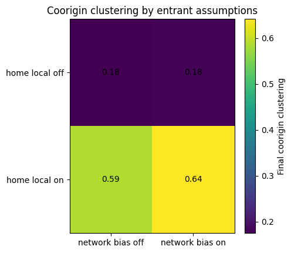

|  | threshold | scenario | move_rate | clustering | target_inflow | chain_share |
| --- | --- | --- | --- | --- | --- | --- |
| 0 | 0.20 | baseline | 0.035 | 0.176 | 0.004 | 0.136 |
| 1 | 0.20 | combined | 0.043 | 0.184 | 0.018 | 0.315 |
| 2 | 0.35 | baseline | 0.039 | 0.176 | 0.005 | 0.134 |
| 3 | 0.35 | combined | 0.047 | 0.197 | 0.021 | 0.361 |
| 4 | 0.50 | baseline | 0.044 | 0.179 | 0.005 | 0.102 |
| 5 | 0.50 | combined | 0.051 | 0.197 | 0.023 | 0.374 |

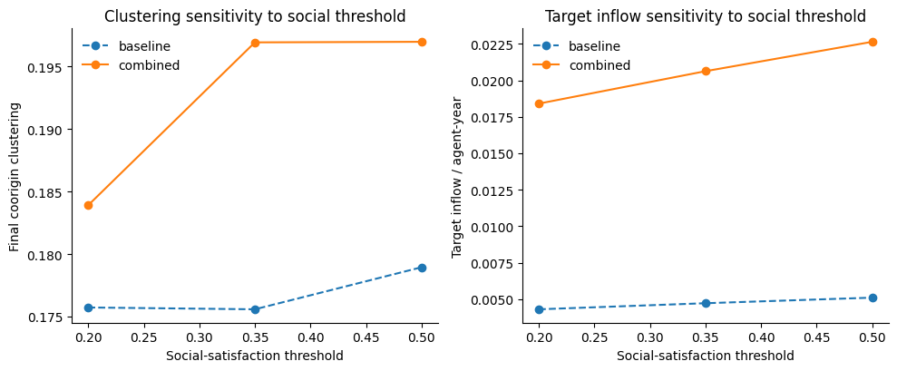

|  | network_homophily_share | scenario | clustering | peer_colocation | target_inflow | chain_share |
| --- | --- | --- | --- | --- | --- | --- |
| 0 | 0.0 | baseline | 0.176 | 0.186 | 0.005 | 0.134 |
| 1 | 0.0 | combined | 0.197 | 0.207 | 0.021 | 0.361 |
| 2 | 0.5 | baseline | 0.177 | 0.186 | 0.005 | 0.140 |
| 3 | 0.5 | combined | 0.198 | 0.212 | 0.022 | 0.395 |

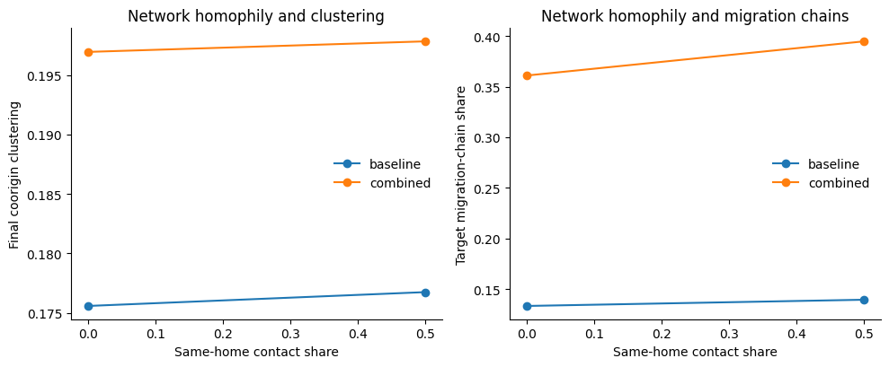

```python
# Entrant-assumption sensitivity heatmap.
pivot = entrant_robustness.pivot_table(index="home_local", columns="network_home_bias", values="coorigin_clustering", aggfunc="mean").reindex(index=[False, True], columns=[False, True])
fig, ax = plt.subplots(figsize=(5.0, 4.4)); im=ax.imshow(pivot.to_numpy(), aspect="auto")
ax.set_xticks([0,1],["network bias off","network bias on"]); ax.set_yticks([0,1],["home local off","home local on"])
for i in range(2):
    for j in range(2): ax.text(j,i,f"{pivot.iloc[i,j]:.2f}",ha="center",va="center")
ax.set_title("Coorigin clustering by entrant assumptions"); fig.colorbar(im,ax=ax,label="Final coorigin clustering"); plt.tight_layout(); plt.show()

threshold_sensitivity = pd.read_csv(RESULT_CACHE / "social_threshold_sensitivity_runs.csv")
threshold_sensitivity_summary = pd.read_csv(RESULT_CACHE / "social_threshold_sensitivity_summary.csv")
display(threshold_sensitivity_summary.round(3))
fig, axes = plt.subplots(1,2,figsize=(10.0,4.2))
for scenario,ls in [("baseline","--"),("combined","-")]:
    g=threshold_sensitivity_summary[threshold_sensitivity_summary.scenario==scenario]
    axes[0].plot(g.threshold,g.clustering,marker="o",linestyle=ls,label=scenario)
    axes[1].plot(g.threshold,g.target_inflow,marker="o",linestyle=ls,label=scenario)
axes[0].set_title("Clustering sensitivity to social threshold"); axes[0].set_ylabel("Final coorigin clustering")
axes[1].set_title("Target inflow sensitivity to social threshold"); axes[1].set_ylabel("Target inflow / agent-year")
for ax in axes: ax.set_xlabel("Social-satisfaction threshold"); ax.legend(frameon=False); ax.spines[["top","right"]].set_visible(False)
plt.tight_layout(); plt.show()

network_homophily_runs = pd.read_csv(RESULT_CACHE / "network_homophily_runs.csv")
network_homophily_summary = pd.read_csv(RESULT_CACHE / "network_homophily_summary.csv")
display(network_homophily_summary.round(3))
fig, axes = plt.subplots(1,2,figsize=(10.0,4.2))
for scenario in ["baseline","combined"]:
    g=network_homophily_summary[network_homophily_summary.scenario==scenario]
    axes[0].plot(g.network_homophily_share,g.clustering,marker="o",label=scenario)
    axes[1].plot(g.network_homophily_share,g.chain_share,marker="o",label=scenario)
axes[0].set_title("Network homophily and clustering"); axes[0].set_ylabel("Final coorigin clustering")
axes[1].set_title("Network homophily and migration chains"); axes[1].set_ylabel("Target migration-chain share")
for ax in axes: ax.set_xlabel("Same-home contact share"); ax.legend(frameon=False); ax.spines[["top","right"]].set_visible(False)
plt.tight_layout(); plt.show()
```

```python
sensitivity_runs = pd.read_csv(RESULT_CACHE / "parameter_sensitivity_runs.csv")
# Only the stay-preference dimension is interpreted; the policy-effect scale is held at 1.0
# (it overlaps with the Section 10 intensity sweep).
stay_sensitivity = sensitivity_runs[sensitivity_runs["policy_scale"] == 1.0].groupby("stay_scale").agg(
    target_inflow=("target_inflow_rate","mean"), social_cost=("target_social_cost","mean"),
    chain_share=("target_chain_share","mean"), clustering=("coorigin_clustering","mean"),
).reset_index()
display(stay_sensitivity.round(3))
```

|  | stay_scale | target_inflow | social_cost | chain_share | clustering |
| --- | --- | --- | --- | --- | --- |
| 0 | 0.85 | 0.030 | -0.132 | 0.479 | 0.224 |
| 1 | 1.00 | 0.021 | -0.108 | 0.361 | 0.197 |
| 2 | 1.15 | 0.015 | -0.091 | 0.291 | 0.179 |

### Housing-price feedback

The rent-feedback elasticity is scanned around the central value 0.15, including `0.0` as the old no-price-feedback control.

V7 uses a **hybrid soft-capacity market** rather than a deterministic hard cutoff: acceptance probability declines smoothly when remaining housing capacity is exhausted, and realized rejection feeds into next-year rents. This keeps finite housing as a real constraint while avoiding an artificial one-unit cliff.

|  | rent_rejection_elasticity | target_inflow | target_housing_rejection | chain_share | final_rent |
| --- | --- | --- | --- | --- | --- |
| 0 | 0.00 | 0.062 | 0.393 | 0.725 | 0.700 |
| 1 | 0.10 | 0.060 | 0.378 | 0.737 | 0.922 |
| 2 | 0.15 | 0.061 | 0.363 | 0.729 | 1.123 |
| 3 | 0.20 | 0.059 | 0.343 | 0.728 | 1.334 |

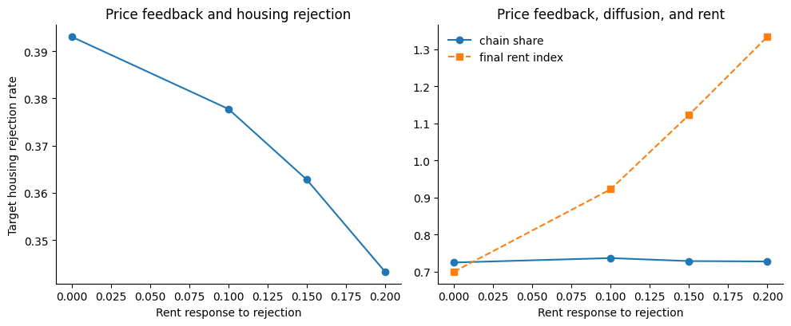

```python
rent_feedback_runs = pd.read_csv(RESULT_CACHE / "rent_feedback_sensitivity_runs.csv")
rent_feedback_summary = pd.read_csv(RESULT_CACHE / "rent_feedback_sensitivity_summary.csv")
display(rent_feedback_summary.round(3))
fig, axes = plt.subplots(1,2,figsize=(10.0,4.2))
axes[0].plot(rent_feedback_summary.rent_rejection_elasticity,rent_feedback_summary.target_housing_rejection,marker="o")
axes[0].set_title("Price feedback and housing rejection"); axes[0].set_xlabel("Rent response to rejection"); axes[0].set_ylabel("Target housing rejection rate")
axes[1].plot(rent_feedback_summary.rent_rejection_elasticity,rent_feedback_summary.chain_share,marker="o",label="chain share")
axes[1].plot(rent_feedback_summary.rent_rejection_elasticity,rent_feedback_summary.final_rent,marker="s",linestyle="--",label="final rent index")
axes[1].set_title("Price feedback, diffusion, and rent"); axes[1].set_xlabel("Rent response to rejection"); axes[1].legend(frameon=False)
for ax in axes: ax.spines[["top","right"]].set_visible(False)
plt.tight_layout(); plt.show()
```

### 13.3 BRFSS directional-validation coverage audit

The review suggested validating the model’s state ranking against BRFSS life satisfaction. V7 first checks whether a common-year eight-state comparison is statistically defensible. The 2023 life-satisfaction item is in BRFSS **Social Determinants and Health Equity** Module 29. CDC’s 2023 module-by-state documentation shows that California, Illinois, Massachusetts, New York (selected questionnaire versions), and North Carolina fielded Social Determinants, while Florida, Texas, and Washington did not.

Therefore an eight-state 2023 Spearman correlation would compare non-comparable missing-by-design samples. V7 **does not manufacture that validation**. The notebook records the coverage audit and treats a complete common-year external subjective-wellbeing validation as future work. This is preferable to reporting a fragile five-state correlation as if it validated all eight states.

Sources: CDC 2023 BRFSS Questionnaire (Module 29) and CDC “2023 Modules by State by Data Set & Weight.”

```python
brfss_coverage = pd.read_csv(RESULT_CACHE / "brfss_2023_coverage_audit.csv")
brfss_validation_status = pd.read_csv(RESULT_CACHE / "brfss_validation_status.csv")
display(brfss_coverage); display(brfss_validation_status)
```

|  | state | social_determinants_module_2023 | life_satisfaction_item_comparable |
| --- | --- | --- | --- |
| 0 | CA | True | True |
| 1 | TX | False | False |
| 2 | NY | True | True |
| 3 | FL | False | False |
| 4 | MA | True | True |
| 5 | NC | True | True |
| 6 | IL | True | True |
| 7 | WA | False | False |

|  | covered_model_states | total_model_states | complete_eight_state_spearman_estimated | reason |
| --- | --- | --- | --- | --- |
| 0 | 5 | 8 | False | 2023 Social Determinants module not fielded in... |

### 13.4 Distance-decay network sensitivity

All 384 rows use the new IRS fit. Recalibrated decay 2 and 5 pass the independent baseline-rate check. The decay-10 candidate fails validation and is retained as a labelled diagnostic only; it is excluded from validated defaults and policy conclusions. Unadjusted network cases are sensitivity scenarios, not separately validated calibration settings.

The new paired strong-minus-weak effects differ by network geography. Among validated recalibrations:

- Decay 0: effect 0.003976; 95% simulation interval [0.001478, 0.006474].
- Decay 2: effect 0.003264; 95% simulation interval [0.001113, 0.005415].
- Decay 5: effect -0.001337; 95% simulation interval [-0.002232, -0.000442].

The decay-5 effect is negative, so positive amplification is not a uniform finding across validated network settings.

|  | recalibrated | network_decay | beta_current_state | same_state_contacts_end | baseline_move_rate | combined_inflow_multiple | combined_chain_share | strong_minus_weak | ci95 | paired_interval_excludes_zero | calibration_validated | scope |
| --- | --- | --- | --- | --- | --- | --- | --- | --- | --- | --- | --- | --- |
| 0 | False | 0.0 | 3.8200 | 0.1869 | 0.0389 | 4.6755 | 0.3979 | 0.0040 | 0.0025 | True | True | baseline/validated control |
| 1 | False | 2.0 | 3.8200 | 0.3343 | 0.0332 | 4.0000 | 0.3577 | 0.0045 | 0.0013 | True | False | unadjusted sensitivity |
| 2 | False | 5.0 | 3.8200 | 0.5525 | 0.0237 | 5.1145 | 0.3432 | 0.0005 | 0.0021 | False | False | unadjusted sensitivity |
| 3 | False | 10.0 | 3.8200 | 0.7476 | 0.0163 | 4.6357 | 0.3123 | -0.0019 | 0.0016 | True | False | failed-fit diagnostic |
| 4 | True | 0.0 | 3.8200 | 0.1869 | 0.0389 | 4.6755 | 0.3979 | 0.0040 | 0.0025 | True | True | baseline/validated control |
| 5 | True | 2.0 | 3.5980 | 0.3311 | 0.0395 | 4.2066 | 0.4131 | 0.0033 | 0.0022 | True | True | baseline/validated control |
| 6 | True | 5.0 | 3.3125 | 0.5245 | 0.0384 | 4.3645 | 0.4281 | -0.0013 | 0.0009 | True | True | baseline/validated control |
| 7 | True | 10.0 | 3.0678 | 0.6659 | 0.0394 | 3.9548 | 0.4498 | -0.0025 | 0.0018 | True | False | failed-fit diagnostic |

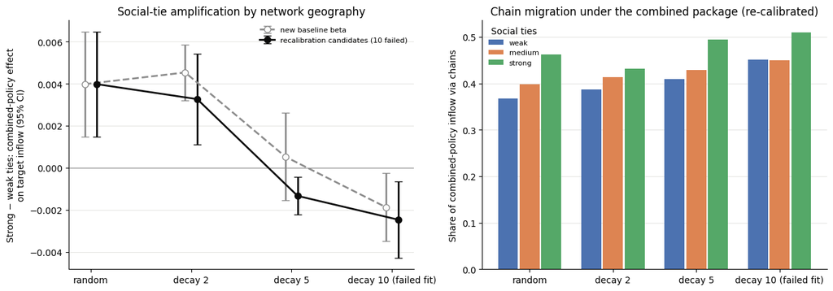

```python
class DistanceDecayABM(PolicySocialABM):
    def __init__(self, *args, network_decay=3.0, **kwargs):
        self.network_decay = float(network_decay)
        super().__init__(*args, **kwargs)
        rng = np.random.default_rng(self.seed + 7000)
        for i in range(len(self.agents)):
            self.network[i] = self._decay_contacts(i, rng)

    def _decay_weights(self, i, candidates):
        d = distance_index.to_numpy()
        s = self._state_indices()
        w = np.exp(-self.network_decay * d[s[i], s[candidates]] / d.max())
        return w / w.sum()

    def _decay_contacts(self, i, rng):
        pool = np.delete(np.arange(len(self.agents)), i)
        return rng.choice(pool, size=self.network_k, replace=False, p=self._decay_weights(i, pool))

    def _rewire_agent(self, i, t):
        rng = self._rng(71 + i % 11, t + i)
        n = len(self.agents)
        self.network[i] = self._decay_contacts(i, rng)
        rows, cols = np.where(self.network == i)
        for r, c in zip(rows, cols):
            candidates = np.setdiff1d(np.arange(n), [r, i])
            self.network[r, c] = int(rng.choice(candidates, p=self._decay_weights(r, candidates)))

NETWORK_DECAYS = [0.0, 2.0, 5.0, 10.0]

def run_decay_case(decay, beta_stay, policy, interaction, seed, recalibrated):
    params = dict(PARAMS, beta_current_state=beta_stay)
    pol = policy_table() if policy == "baseline" else policy_table(FOCAL_STATE, housing=1.0, employment=1.0, migration_incentive=1.0)
    kw = dict(seed=seed, interaction_strength=INTERACTION_LEVELS[interaction], params=params)
    model = PolicySocialABM(state_data, pol, **kw) if decay == 0 else DistanceDecayABM(state_data, pol, network_decay=decay, **kw)
    history, _, _ = model.run()
    s = model._state_indices()
    return {"network_decay": decay, "beta_current_state": beta_stay, "recalibrated": recalibrated, "policy": policy,
            "interaction": interaction, "seed": seed, "move_rate": history.groupby("year").first()["move_rate"].mean(),
            "same_state_contact_share": float(np.mean(s[model.network] == s[:, None])),
            **summarise_v7_run(model, history, FOCAL_STATE)}

decay_path = RESULT_CACHE / "network_decay_runs.csv"
if decay_path.exists():
    decay_runs = pd.read_csv(decay_path)
else:
    raise FileNotFoundError("Run python research/build_research.py before building the report.")

def strong_minus_weak(runs, keys, metric="target_inflow_rate"):
    rows = []
    for k, g in runs.groupby(keys):
        w = g.pivot_table(index=["interaction", "seed"], columns="policy", values=metric)
        eff = w["combined"] - w["baseline"]
        d = (eff.xs("strong") - eff.xs("weak")).to_numpy()
        rows.append({**dict(zip(keys, k if isinstance(k, tuple) else (k,))), "strong_minus_weak": d.mean(),
                     "ci95": student_t.ppf(0.975, len(d) - 1) * d.std(ddof=1) / np.sqrt(len(d))})
    return pd.DataFrame(rows)

med = decay_runs[decay_runs["interaction"] == "medium"]
decay_table = med.pivot_table(index=["recalibrated", "network_decay"], columns="policy",
                              values=["target_inflow_rate", "chain_share", "move_rate", "same_state_contact_share"])
decay_summary = pd.DataFrame({
    "beta_current_state": med.groupby(["recalibrated", "network_decay"])["beta_current_state"].first(),
    "same_state_contacts_end": decay_table[("same_state_contact_share", "baseline")],
    "baseline_move_rate": decay_table[("move_rate", "baseline")],
    "combined_inflow_multiple": decay_table[("target_inflow_rate", "combined")] / decay_table[("target_inflow_rate", "baseline")],
    "combined_chain_share": decay_table[("chain_share", "combined")],
}).reset_index().merge(strong_minus_weak(decay_runs, ["recalibrated", "network_decay"]), on=["recalibrated", "network_decay"])
decay_summary["paired_interval_excludes_zero"] = (decay_summary["strong_minus_weak"].abs() > decay_summary["ci95"])
decay_summary["calibration_validated"] = decay_summary.apply(lambda r: bool(float(r.network_decay) == 0 or (r.recalibrated and str(float(r.network_decay)) in FITTED_CONFIG["network_beta_by_decay"])), axis=1)
decay_summary["scope"] = decay_summary.apply(lambda r: "failed-fit diagnostic" if r.network_decay == 10 else ("baseline/validated control" if r.calibration_validated else "unadjusted sensitivity"), axis=1)
display(decay_summary.round(4))

fig, axes = plt.subplots(1, 2, figsize=(13.0, 4.6))
ax = axes[0]
for recal, style in [(False, dict(color="#8c8c8c", marker="o", mfc="#fcfcfb", linestyle="--", label="new baseline beta")),
                     (True, dict(color="#0b0b0b", marker="o", linestyle="-", label="recalibration candidates (10 failed)"))]:
    g = decay_summary[decay_summary["recalibrated"] == recal]
    x = np.arange(len(g)) + (0.06 if recal else -0.06)
    ax.errorbar(x, g["strong_minus_weak"], yerr=g["ci95"], capsize=4, lw=2, ms=7, **style)
ax.axhline(0, color="#8c8c8c", lw=0.8)
ax.set_xticks(range(len(NETWORK_DECAYS)), [f"random" if d == 0 else f"decay {d:g}{' (failed fit)' if d == 10 else ''}" for d in NETWORK_DECAYS])
ax.set_ylabel("Strong − weak ties: combined-policy effect\non target inflow (95% CI)")
ax.set_title("Social-tie amplification by network geography")
ax.legend(frameon=False, fontsize=8)
ax = axes[1]
g = decay_runs[(decay_runs["recalibrated"]) & (decay_runs["policy"] == "combined")].groupby(["network_decay", "interaction"])["chain_share"].mean().unstack()
for k, inter in enumerate(SWEEP_INTERACTIONS):
    ax.bar(np.arange(len(g)) + (k - 1) * 0.26, g[inter], width=0.24, color=INTERACTION_COLORS[inter], label=inter)
ax.set_xticks(range(len(g)), [f"random" if d == 0 else f"decay {d:g}{' (failed fit)' if d == 10 else ''}" for d in g.index])
ax.set_ylabel("Share of combined-policy inflow via chains")
ax.set_title("Chain migration under the combined package (re-calibrated)")
ax.legend(title="Social ties", frameon=False, fontsize=8)
for ax in axes:
    ax.grid(axis="y", color="#e6e6e3", linewidth=0.8); ax.set_axisbelow(True)
    ax.spines[["top", "right"]].set_visible(False)
plt.tight_layout(); plt.show()
```

### 13.5 Open-system competition

The reconstructed PUMS outside-eight-state origin share is 0.6202649263910248. The fitted entry-attempt rate is 0.0940 for shared capacity and 0.0678 for scaled capacity, each checked on independent seeds. All open-system policy rows are rerun using the new IRS and stay parameters. Capacity scaling and the simplified outside-origin pool remain structural assumptions. Internal and total inflow use consistent agent-year denominators.

For the intensity-1 combined package at medium ties, newly simulated mean total-inflow multiples over each model's own baseline are closed: 4.675, open (scaled): 4.026, open (shared): 2.085. Absolute increments are closed: 0.016910, open (scaled): 0.037882, open (shared): 0.014670 per agent-year. Relative and absolute comparisons answer different questions and depend on the capacity rule.

```python
EXTERNAL_ORIGIN_TARGET = FITTED_CONFIG["external_origin_target"]  # ACS PUMS share of in-movers arriving from other US states (Section 3.1)

def cross_policy(policy, intensity):
    # Section 9 design: each active single lever carries a 0.5 x intensity migration incentive.
    if policy == "baseline":
        return policy_table()
    h = intensity if policy in ("housing", "combined") else 0.0
    e = intensity if policy in ("employment", "combined") else 0.0
    return policy_table(FOCAL_STATE, housing=h, employment=e, migration_incentive=0.5 * intensity * ((h > 0) + (e > 0)))

class OpenSystemABM(PolicySocialABM):
    def __init__(self, *args, external_rate=0.05, capacity_mode="shared", **kwargs):
        self.external_rate = float(external_rate)
        self.capacity_mode = capacity_mode
        self.external_rows = []
        super().__init__(*args, **kwargs)

    def _housing_slots(self):
        hh = self.agents.groupby("state")["household_id"].nunique().reindex(STATE_CODES, fill_value=0).to_numpy()
        return np.maximum(1, np.round(
            hh * self.base_state["vacancy_rate"].to_numpy() * self.params["housing_entry_factor"]
            + hh * self.policies["housing_policy"].to_numpy() * self.params["housing_policy_slots"])).astype(int)

    def _outsider_utility(self):
        wage, jobs, rent = self.state["wage_index"].to_numpy(), self.state["job_index"].to_numpy(), self.state["rent_index"].to_numpy()
        income_anchor = 0.65 * self.base_state["median_household_income"].to_numpy() * (wage / self.base_state["wage_index"].to_numpy())
        return (self.params["beta_income"] * np.log(income_anchor / np.median(income_anchor))
                + self.params["beta_jobs"] * jobs - self.params["beta_rent"] * rent
                + DESTINATION_EFFECTS.to_numpy()
                + self.params["beta_housing_signal"] * self.policies["housing_policy"].to_numpy()
                + self.params["beta_employment_signal"] * self.policies["employment_incentive"].to_numpy()
                + self.params["beta_migration_incentive"] * self.policies["migration_incentive"].to_numpy())

    def _external_exchange(self, t, remaining, nominal, internal_prop, internal_rej):
        a = self.agents; S = len(STATE_CODES); rng = self._rng(97, t)
        z = self._outsider_utility() / self.params["temperature"]
        p = np.exp(z - z.max()); p /= p.sum()
        n_try = int(rng.poisson(self.external_rate * len(a)))
        softness = max(float(self.params.get("housing_market_softness", 0.10)), 1e-4)
        buffer = float(self.params.get("housing_capacity_buffer", 0.05))
        prop = np.zeros(S, dtype=int); rej = np.zeros(S, dtype=int); acc = np.zeros(S, dtype=int)
        arrivals = []
        for dest in rng.choice(S, size=n_try, p=p):
            prop[dest] += 1
            if rng.random() > float(logistic((remaining[dest] / max(nominal[dest], 1.0) - buffer) / softness)):
                rej[dest] += 1
            else:
                acc[dest] += 1; remaining[dest] -= 1; arrivals.append(int(dest))
        leavers = rng.choice(len(a), size=len(arrivals), replace=False) if arrivals else np.array([], dtype=int)
        pop_p = self.base_state["young_adult_population_est_18_35"].to_numpy(dtype=float); pop_p /= pop_p.sum()
        for i, dest in zip(leavers, arrivals):
            state = STATE_CODES[dest]
            age = int(np.clip(np.rint(rng.normal(26, 4.5)), 18, 35))
            college_p = self.base_state.loc[state, "college_share_proxy"] * (0.2 if age < 22 else 0.6 if age < 25 else 1.0)
            college = int(rng.binomial(1, np.clip(college_p, 0.03, 0.75)))
            skill = float(np.clip(rng.normal(1.0 + 0.18 * college, 0.15), 0.55, 1.65))
            a.loc[i, ["age", "college", "skill", "state", "home_state", "is_international", "employed", "has_children",
                      "dependent_children", "unemployed_years", "job_rejected_last_year", "last_move_year"]] = [
                age, college, skill, state, rng.choice(STATE_CODES, p=pop_p), 0, 0, 0, 0, 0, 0, t]
            a.loc[i, "income"] = (0.65 * self.base_state.loc[state, "median_household_income"]
                                  * (0.72 + 0.28 * skill) * (1 + 0.22 * college) * rng.lognormal(0, 0.12))
            a.loc[i, "household_id"] = self.next_household_id; self.next_household_id += 1
            self._rewire_agent(int(i), t)
        # Price feedback sees insider and outsider rejections together.
        tot_p, tot_r = internal_prop + prop, internal_rej + rej
        self.housing_rejection_by_state[t] = {s: tot_r[j] / max(tot_p[j], 1) for j, s in enumerate(STATE_CODES)}
        f = STATE_CODES.index(FOCAL_STATE)
        self.external_rows.append({"year": BASE_YEAR + t + 1, "external_attempts": n_try, "external_accepted": int(acc.sum()),
                                   "target_external_proposed": int(prop[f]), "target_external_accepted": int(acc[f]),
                                   "target_external_rejected": int(rej[f])})

    def step(self, t):
        self._demography_step(t)
        self._household_formation_step(t)
        births = self._family_step(t)
        slots0 = self._housing_slots()
        hh_state = self.agents.groupby("household_id")["state"].first()
        n_dec = len(self.decision_rows)
        old_states, new_states, proposed, rejected = self._migration_step(t)
        new_hh_state = self.agents.groupby("household_id")["state"].first().reindex(hh_state.index)
        moved = hh_state != new_hh_state
        into = new_hh_state[moved].value_counts().reindex(STATE_CODES, fill_value=0).to_numpy()
        outof = hh_state[moved].value_counts().reindex(STATE_CODES, fill_value=0).to_numpy()
        factor = 1.0 / (1.0 - EXTERNAL_ORIGIN_TARGET) if self.capacity_mode == "scaled" else 1.0
        remaining = (slots0 - into + outof + slots0 * (factor - 1.0)).astype(float)
        dec = pd.DataFrame(self.decision_rows[n_dec:])
        prop_int = dec[dec["proposed_move"] == 1].groupby("chosen_destination").size().reindex(STATE_CODES, fill_value=0).to_numpy()
        rej_int = dec[dec["housing_rejected"] == 1].groupby("chosen_destination").size().reindex(STATE_CODES, fill_value=0).to_numpy()
        self._external_exchange(t, remaining, slots0 * factor, prop_int, rej_int)
        self._employment_step(t)
        self._environment_step()
        self._record_metrics(t, old_states, new_states, proposed, rejected, births)
        if t + 1 in {5, 10, 15, 20}:
            self._snapshot(BASE_YEAR + t + 1)
```

|  | capacity_mode | external_rate | external_share_no_policy |
| --- | --- | --- | --- |
| 0 | scaled | 0.0678 | 0.6174 |
| 1 | shared | 0.0940 | 0.6200 |

|  | model | policy | effect_internal | effect_total | multiple_total | housing_rejection |
| --- | --- | --- | --- | --- | --- | --- |
| 0 | closed | housing | 0.0050 | 0.0050 | 2.0943 | 0.0173 |
| 1 | open (scaled) | housing | 0.0054 | 0.0117 | 1.9362 | 0.0029 |
| 2 | open (shared) | housing | 0.0053 | 0.0099 | 1.7304 | 0.2221 |
| 3 | closed | employment | 0.0057 | 0.0057 | 2.2340 | 0.0886 |
| 4 | open (scaled) | employment | 0.0067 | 0.0143 | 2.1429 | 0.0724 |
| 5 | open (shared) | employment | 0.0051 | 0.0011 | 1.0796 | 0.5717 |
| 6 | closed | combined | 0.0169 | 0.0169 | 4.6755 | 0.0926 |
| 7 | open (scaled) | combined | 0.0193 | 0.0379 | 4.0264 | 0.0393 |
| 8 | open (shared) | combined | 0.0154 | 0.0147 | 2.0847 | 0.5222 |

|  | capacity_mode | strong_minus_weak | ci95 | inflow |
| --- | --- | --- | --- | --- |
| 0 | scaled | 0.0077 | 0.0023 | inflow |
| 1 | shared | 0.0030 | 0.0019 | inflow |
| 2 | scaled | 0.0074 | 0.0024 | total_inflow |
| 3 | shared | 0.0001 | 0.0021 | total_inflow |
| 4 | closed | 0.0040 | 0.0025 | inflow |

|  | model | inflow | response90_median | gain_at_6 |
| --- | --- | --- | --- | --- |
| 0 | closed | inflow | 3.5 | 0.1014 |
| 1 | closed | total_inflow | 3.5 | 0.1014 |
| 2 | scaled | inflow | 3.5 | 0.0907 |
| 3 | scaled | total_inflow | 3.5 | 0.1493 |
| 4 | shared | inflow | 3.5 | 0.0978 |
| 5 | shared | total_inflow | 5.0 | 0.1418 |

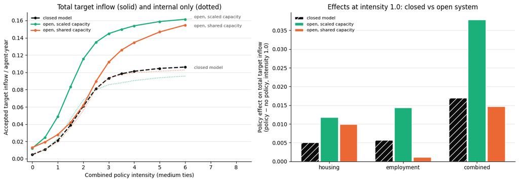

```python
def run_open_case(mode, rate, design, policy, intensity, interaction, seed):
    model = OpenSystemABM(state_data, cross_policy(policy, intensity) if intensity > 0 else policy_table(), seed=seed,
                          interaction_strength=INTERACTION_LEVELS[interaction], external_rate=rate, capacity_mode=mode)
    history, _, _ = model.run()
    mech, ext = model.mechanism_history(), pd.DataFrame(model.external_rows)
    agent_years = history.groupby("year")["population"].sum().sum()
    internal_movers = (history.groupby("year").first()["move_rate"] * history.groupby("year")["population"].sum()).sum()
    accepted = mech["target_accepted"].sum()
    return {"capacity_mode": mode, "external_rate": rate, "design": design, "policy": policy, "intensity": intensity,
            "interaction": interaction, "seed": seed,
            "target_inflow_rate": accepted / agent_years,
            "target_total_inflow_rate": (accepted + ext["target_external_accepted"].sum()) / agent_years,
            "chain_share": mech["target_chain_moves"].sum() / max(accepted, 1),
            "housing_rejection": (mech["target_housing_rejected"].sum() + ext["target_external_rejected"].sum())
                                 / max(mech["target_proposed"].sum() + ext["target_external_proposed"].sum(), 1),
            "external_share_system": ext["external_accepted"].sum() / max(ext["external_accepted"].sum() + internal_movers, 1)}

open_path = RESULT_CACHE / "open_system_runs.csv"
if open_path.exists():
    open_runs = pd.read_csv(open_path)
else:
    raise FileNotFoundError("Run python research/build_research.py before building the report.")

# Calibration check and effects at intensity 1.0 (medium ties), against the closed Section 9 results.
cross_open = open_runs[(open_runs["design"] == "cross") & (open_runs["interaction"] == "medium")]
calib = cross_open[cross_open["policy"] == "baseline"].groupby("capacity_mode").agg(
    external_rate=("external_rate", "first"), external_share_no_policy=("external_share_system", "mean")).reset_index()
display(calib.round(4))
closed = cross_summary[cross_summary["interaction"] == "medium"].set_index("policy")
rows = []
for policy in ["housing", "employment", "combined"]:
    base, pol = closed.loc["baseline", "target_inflow_rate"], closed.loc[policy, "target_inflow_rate"]
    rows.append({"model": "closed", "policy": policy, "effect_internal": pol - base, "effect_total": pol - base,
                 "multiple_total": pol / base, "housing_rejection": closed.loc[policy, "housing_rejection"]})
    for mode, g in cross_open.groupby("capacity_mode"):
        m = g.groupby("policy")[["target_inflow_rate", "target_total_inflow_rate", "housing_rejection"]].mean()
        rows.append({"model": f"open ({mode})", "policy": policy,
                     "effect_internal": m.loc[policy, "target_inflow_rate"] - m.loc["baseline", "target_inflow_rate"],
                     "effect_total": m.loc[policy, "target_total_inflow_rate"] - m.loc["baseline", "target_total_inflow_rate"],
                     "multiple_total": m.loc[policy, "target_total_inflow_rate"] / m.loc["baseline", "target_total_inflow_rate"],
                     "housing_rejection": m.loc[policy, "housing_rejection"]})
open_effects = pd.DataFrame(rows)
display(open_effects.round(4))

amp = []
for metric in ["target_inflow_rate", "target_total_inflow_rate"]:
    t_ = strong_minus_weak(open_runs[open_runs["design"] == "cross"], ["capacity_mode"], metric)
    amp.append(t_.assign(inflow=metric.replace("target_", "").replace("_rate", "")))
closed_amp = policy_effects[(policy_effects["policy"] == "combined") & (policy_effects["metric"] == "d_target_inflow_rate")]
amp.append(pd.DataFrame({"capacity_mode": ["closed"], "strong_minus_weak": closed_amp["strong_minus_weak_policy_effect"].to_numpy(),
                         "ci95": closed_amp["ci95_half_width"].to_numpy(), "inflow": ["inflow"]}))
display(pd.concat(amp, ignore_index=True).round(4))

sweep_open = open_runs[open_runs["design"] == "sweep"].rename(columns={"intensity": "policy_intensity"})
closed_sweep = sweep_runs[sweep_runs["interaction"] == "medium"].assign(capacity_mode="closed", target_total_inflow_rate=lambda d: d["target_inflow_rate"])
all_sweep = pd.concat([closed_sweep, sweep_open], ignore_index=True)
sat_rows = []
for mode, g in all_sweep.groupby("capacity_mode"):
    for col in ["target_inflow_rate", "target_total_inflow_rate"]:
        thr = thresholds_by_seed(g, ["capacity_mode"], x_col="policy_intensity", y=col)
        curve = g.groupby("policy_intensity")[col].mean()
        sat_rows.append({"model": mode, "inflow": col.replace("target_", "").replace("_rate", ""),
                         "response90_median": thr["response90"].median(), "gain_at_6": curve.iloc[-1] - curve.iloc[0]})
display(pd.DataFrame(sat_rows).round(4))

MODEL_STYLES = {"closed": dict(color="#0b0b0b", linestyle="--"), "scaled": dict(color="#1baf7a"), "shared": dict(color="#eb6834")}
MODEL_LABELS = {"closed": "closed model", "scaled": "open, scaled capacity", "shared": "open, shared capacity"}
fig, axes = plt.subplots(1, 2, figsize=(13.5, 4.8))
ax = axes[0]
end_labels = []
for mode in ["closed", "scaled", "shared"]:
    g = all_sweep[all_sweep["capacity_mode"] == mode].groupby("policy_intensity")[["target_total_inflow_rate", "target_inflow_rate"]].mean()
    ax.plot(g.index, g["target_total_inflow_rate"], marker="o", ms=4, lw=2, label=MODEL_LABELS[mode], **MODEL_STYLES[mode])
    if mode != "closed":
        ax.plot(g.index, g["target_inflow_rate"], lw=1.2, alpha=0.8, color=MODEL_STYLES[mode]["color"], linestyle=":")
    end_labels.append((g["target_total_inflow_rate"].iloc[-1], MODEL_LABELS[mode]))
ax.set_xlim(-0.2, 8.6)
spread_labels(ax, end_labels, max(EXTENDED_INTENSITIES), min_gap_frac=0.06)
ax.set_xlabel("Combined policy intensity (medium ties)")
ax.set_ylabel("Accepted target inflow / agent-year")
ax.set_title("Total target inflow (solid) and internal only (dotted)")
ax.legend(frameon=False, fontsize=8, loc="upper left")
ax = axes[1]
order = ["housing", "employment", "combined"]
for k, mode in enumerate(["closed", "scaled", "shared"]):
    label = "closed" if mode == "closed" else f"open ({mode})"
    g = open_effects[open_effects["model"] == label].set_index("policy").loc[order]
    ax.bar(np.arange(3) + (k - 1) * 0.26, g["effect_total"], width=0.24, color=MODEL_STYLES[mode]["color"],
           hatch="//" if mode == "closed" else None, edgecolor="#fcfcfb", label=MODEL_LABELS[mode])
ax.axhline(0, color="#8c8c8c", lw=0.8)
ax.set_xticks(range(3), order)
ax.set_ylabel("Policy effect on total target inflow\n(policy − no policy, intensity 1.0)")
ax.set_title("Effects at intensity 1.0: closed vs open system")
ax.legend(frameon=False, fontsize=8)
for ax in axes:
    ax.grid(axis="y", color="#e6e6e3", linewidth=0.8); ax.set_axisbelow(True)
    ax.spines[["top", "right"]].set_visible(False)
plt.tight_layout(); plt.show()
```

### Reproducibility checks

The following cell repeats four independent live policy/sweep cases and compares their common metrics with the regenerated cache at tolerance 1e-9. Use `requirements-project.txt` with Python 3.10.18 for the pinned verification environment. No historical cache is used by this report.

```python
import importlib.metadata as _md, platform, datetime

def live_summary(target_state, policy_df, interaction, seed):
    global FOCAL_STATE
    saved_focal, FOCAL_STATE = FOCAL_STATE, target_state
    try:
        model = PolicySocialABM(state_data, policy_df, seed=seed, interaction_strength=INTERACTION_LEVELS[interaction])
        history, _, _ = model.run()
        return summarise_v7_run(model, history, target_state)
    finally:
        FOCAL_STATE = saved_focal

# Cached column names differ slightly between batches; compare every metric both sides have.
CROSS_COLUMN_ALIASES = {"target_inflow_rate": ["target_inflow_rate"],
                        "chain_share": ["target_chain_share", "chain_share"],
                        "target_social_cost": ["target_social_cost", "social_cost"],
                        "housing_rejection": ["target_housing_rejection", "housing_rejection"],
                        "coorigin_clustering": ["coorigin_clustering", "clustering"]}

def compare(label, live, cached_row, aliases):
    checked = []
    for key, names in aliases.items():
        name = next((n for n in names if n in cached_row.index), None)
        if name is None:
            continue
        diff = abs(float(live[key]) - float(cached_row[name]))
        assert diff < 1e-9, f"{label}: {key} live={live[key]:.6f} cached={cached_row[name]:.6f}"
        checked.append(key)
    assert "target_inflow_rate" in checked, f"{label}: cached row has no target_inflow_rate"
    return {"case": label, "metrics_checked": len(checked), "target_inflow_rate": live["target_inflow_rate"], "status": "match"}

rows = []
for policy in ["baseline", "combined"]:
    seed = CROSS_SEEDS[0]
    cached = cross_runs[(cross_runs["policy"] == policy) & (cross_runs["interaction"] == "medium") & (cross_runs["seed"] == seed)].iloc[0]
    live = live_summary(FOCAL_STATE, cross_policy(policy, STANDARD_INTENSITY), "medium", seed)
    rows.append(compare(f"cross: {policy}, medium, seed {seed}", live, cached, CROSS_COLUMN_ALIASES))
same = {k: [k] for k in ["target_inflow_rate", "target_social_cost", "chain_share", "housing_rejection", "job_rejection", "coorigin_clustering"]}
for runs, target_state, lever, x, inter in [(lever_runs, FOCAL_STATE, "housing", 3.0, "strong"),
                                             (state_runs, "CA", "combined", 2.0, "weak")]:
    seed = SWEEP_SEEDS[0]
    cached = runs[(runs["target_state"] == target_state) & (runs["lever"] == lever) & (runs["intensity"] == x)
                  & (runs["interaction"] == inter) & (runs["seed"] == seed)].iloc[0]
    live = live_summary(target_state, lever_policy(target_state, lever, x), inter, seed)
    rows.append(compare(f"sweep: {target_state} {lever} {x:g}, {inter}, seed {seed}", live, cached, same))
display(pd.DataFrame(rows))

stamps = pd.DataFrame([{"file": p.name, "modified": datetime.datetime.fromtimestamp(p.stat().st_mtime).strftime("%Y-%m-%d %H:%M")}
                       for p in sorted(RESULT_CACHE.glob("*.csv"))])
print(f"{len(stamps)} cached CSV files; newest {stamps['modified'].max()}, oldest {stamps['modified'].min()}")
print("Python", platform.python_version(), "|", ", ".join(f"{p} {_md.version(p)}" for p in ["numpy", "pandas", "scipy", "matplotlib", "joblib"]))
```

|  | case | metrics_checked | target_inflow_rate | status |
| --- | --- | --- | --- | --- |
| 0 | cross: baseline, medium, seed 201 | 5 | 0.005139 | match |
| 1 | cross: combined, medium, seed 201 | 5 | 0.019583 | match |
| 2 | sweep: NY housing 3, strong, seed 301 | 6 | 0.014722 | match |
| 3 | sweep: CA combined 2, weak, seed 301 | 6 | 0.066250 | match |

```
29 cached CSV files; newest 2026-10-09 21:27, oldest 2026-10-09 21:27
Python 3.10.18 | numpy 2.2.6, pandas 2.3.3, scipy 1.15.3, matplotlib 3.10.6, joblib 1.5.3
```

## 14. Interactive migration replay

Replay actual accepted agent moves in the closed eight-state model. Compare no policy with the intensity-1 combined policy at the same seed (201), 600 agents and 12 years. Play/pause, scrub the timeline, change speed or switch scenario. Gold dots mark the model's social-chain moves.

Each dot represents one accepted move; annual route counts and state inflows/outflows are checked before rendering. The model runs annually: within-year timing and curved travel paths are illustrative. Node labels show end-year residents, including demographic replacement.

Trust the notebook to enable the embedded animation, or open the exported `results/research/migration-animation.html` in a browser. The export is self-contained and needs no network connection. This section runs two new model instances and preserves the preceding analysis.

```python
from migration_animation import make_comparison

migration_replay = make_comparison(
    globals(), n_agents=EXPERIMENT_AGENTS, years=EXPERIMENT_YEARS, seed=CROSS_SEEDS[0]
)
migration_replay_path = migration_replay.save(PROJECT_ROOT / "results/research/migration-animation.html")
print("Offline animation:", migration_replay_path.resolve())
display(migration_replay)
```

```
Offline animation: D:\uni\cits4403\project\pr1\project-finalization\results\research\migration-animation.html
```

[interactive chart not shown]

```python
# Export the computed report tables as reviewable numerical evidence.
REPORT_TABLES = ["baseline_summary", "cross_summary", "interaction_modification", "power_table", "threshold_summary", "cost_curve", "cost_kink_summary", "robustness", "lever_saturation", "state_saturation", "shock_summary", "competition_summary", "decay_summary", "open_effects"]
evidence_dir = PROJECT_ROOT / "results/research/tables"
evidence_dir.mkdir(parents=True, exist_ok=True)
for name in REPORT_TABLES:
    if isinstance(globals().get(name), pd.DataFrame):
        globals()[name].to_csv(evidence_dir / (name + ".csv"), index=True)
pd.DataFrame(rows).to_csv(evidence_dir / "live-checks.csv", index=False)
pd.concat(amp, ignore_index=True).to_csv(evidence_dir / "open-amplification.csv", index=False)
pd.DataFrame(sat_rows).to_csv(evidence_dir / "open-saturation.csv", index=False)
print("Research evidence exported", evidence_dir)

import hashlib
report_profile = {"profile": "calibrated-research", "parameters_sha256": hashlib.sha256((PROJECT_ROOT / "calibration/reliable-calibration/parameters.json").read_bytes()).hexdigest(), "live_checks": len(rows), "live_metric_checks": sum(r["metrics_checked"] for r in rows)}
(PROJECT_ROOT / "results/research/profile.json").write_text(json.dumps(report_profile, indent=2), encoding="utf-8")
```

```
Research evidence exported D:\uni\cits4403\project\pr1\project-finalization\results\research\tables
```

```
177
```